# **Facial Emotion Detection**

# **Executive Summary**

Based on the findings from the previous analysis, this project proposes VGG16 as a model to detect emotion from pictures of faces. This was found to show the most promise in being able to achieve a higher accuracy without overfitting to the data out of all the models tested. The model uses transfer learning from VGG16 trained on the imagenet dataset up to the block5_conv1 layer. It then has a fully connected layer followed by a dropout layer and uses the following parameters:

- learning_rate: 0.00011
- dropout_rate: 0.054
- num_fc_layers: 1
- neurons_layer_0: 211
- batch_size: 105  
  The model was trained on a dataset consisting of low quality greyscale images with size of 48x48, so may not generalize well to color images or higher resolution images. While in the case of training, the class 'neutral' had the best f1 score, the final model perfoms much better on the 'surprised' class, followed by the 'happy' class.

# **Problem and solution summary**

Facial emotion detection can be used in a variety of areas, including:

- Public saftey
  - Used to detect unusual behavior and potential threats
- Gaming
  - Can be used to adapt the difficulty of a game based on frustration or other emotions
  - Can be used to intensify the atmosphere and suspense in horror games based on fear
  - Can be used to change the facial expression of the players avatar based on how they are feeling
- Automotive industry
  - Can be used to enhance safety by monitoring the drivers emotional state

## **Solution design**

6 different models were tested for the purpose of this project. 3 CNNs with varying complexity, and 3 models via transfer learning, namely VGG16, ResNet nad EfficientNet. ResNet and EfficientNet were found to perform poorly on the data, possibly because the dataset is not complex enough to take advantange of the architecture of these models. While some results from the CNNs seemed to show a higher accuracy, they performed much better on the neutral class, and in the test set there were a higher amount of this class, so overfitting was potentially the reason for that. Because of this, VGG16 was chosen.  
Once VGG16 was decided on, I performed hyperparameter tuning using optuna over 50 trials, resulting in the choices mentioned above. After this, I fine-tuned the model by unfreezing the weights of all layers and training it with a small learning rate, resulting in a 0.5% increase in validation accuracy, to around 64%. I tried freezing the weights after this and training with SGD as the optimizer and a small learning rate but no improvement was found. The final model performed well on a test set, with an accuracy of 81%, but due to it having an f1 score of 1 for 'surprise' and 0.86 for 'happy', which were the majority of the data, towards other emotions it would not perform as well.  
Based on the results, this model would not be suitable for use in its current state. While it may be used for testing concepts in gaming, applications to other more important areas like public safety would require a much higher accuracy. Therefore, without further improvement, using the model as it is could have potentially catastrophic effects.

# **Further analysis and implementation**

As the model still showed signs of overfitting, testing out different architectures, either of the same model or using transfer learning on more up-to-date models, before tuning hyperparameters would be my next step for improvement. Adding Batch Normalization, and using Grid Search over the dropout rate and number of neurons in each layer could be used to find the most optimal architecture, however this could be expensive as it performs an exhaustive search. A larger number of trials using optuna could've been used to, and over a greater number of epochs than 10. Each trial took approximately 6-7 minutes to complete over the hyperparameters used in this project, taking almost 6 hours for 50 trials, so if enough computational power or time is available, a larger number of trials can be explored.  
As this model performed extremely well on the 'surprise' class, one possible solution would be to train models looking for similar performance on the other classes, and then using an ensemble technique to make predictions based on all 4 algorithms is also another direction that could possibly yield a much better performance without the need to gather more data. However, the process of training 3 more models will obviously require a much longer amount of time than training one. If enough computing resources are available to train them at the same time however, a lot of this extra time can be mitigated  
The best choice for improving the performance of the model would be to gather much more data. Although this can be a time consuming process, as the model can't be feasibly used in its current state, this would be the recommendation for the next step to make improvements to the model.

## **Problem Definition**

**The context:** Why is this problem important to solve?  
**The objectives:** What is the intended goal?  
**The key questions:** What are the key questions that need to be answered?  
**The problem formulation:** What are we trying to solve using data science?

## **About the dataset**

The data set consists of 3 folders, i.e., 'test', 'train', and 'validation'. Each of these folders has four subfolders:

**‘happy’**: Images of people who have happy facial expressions.  
**‘sad’**: Images of people with sad or upset facial expressions.  
**‘surprise’**: Images of people who have shocked or surprised facial expressions.  
**‘neutral’**: Images of people showing no prominent emotion in their facial expression at all.

## **Mounting the Drive**

**NOTE:** Please use Google Colab from your browser for this notebook. **Google.colab is NOT a library that can be downloaded locally on your device.**

```python
# Mounting the drive
from google.colab import drive
drive.mount('/content/drive')
```

## **Importing the Libraries**

```python
# Basic libraries
import numpy as np
import pandas as pd
import tensorflow as tf
import random

# Visualization libraries
import matplotlib.pyplot as plt
import seaborn as sns

# Preprocessing libraries
from tensorflow.keras.preprocessing.image import load_img, ImageDataGenerator

# Deep learning libraries
from tensorflow.keras.layers import Dense, Conv2D, MaxPooling2D, Flatten, Activation, LeakyReLU, Dropout, BatchNormalization
from tensorflow.keras.models import Sequential
from tensorflow.keras.optimizers import Adam
from keras.callbacks import ModelCheckpoint, EarlyStopping, ReduceLROnPlateau

# Import Keras backend
from tensorflow.keras import backend

from sklearn.metrics import confusion_matrix, classification_report

# File handling libraries
import zipfile
import os
```

[output not shown]

### **Let us load and unzip the data**

**Note:**

- You must download the dataset from the link provided on Olympus and upload the same on your Google drive before executing the code in the next cell.
- In case of any error, please make sure that the path of the file is correct as the path may be different for you.

```python
# Path of dataset zip file
path = '/content/drive/MyDrive/Facial_emotion_images.zip'

# Extracting files
with zipfile.ZipFile(path, 'r') as zip_ref:
    zip_ref.extractall()
```

```python
# Define the size of the images and the path to where the data was unzipped
image_size = 48
folder_path = '/content/Facial_emotion_images'
```

## **Visualizing our Classes**

Let's look at our classes.

**Write down your observation for each class. What do you think can be a unique feature of each emotion, that separates it from the remaining classes?**

### **Happy**

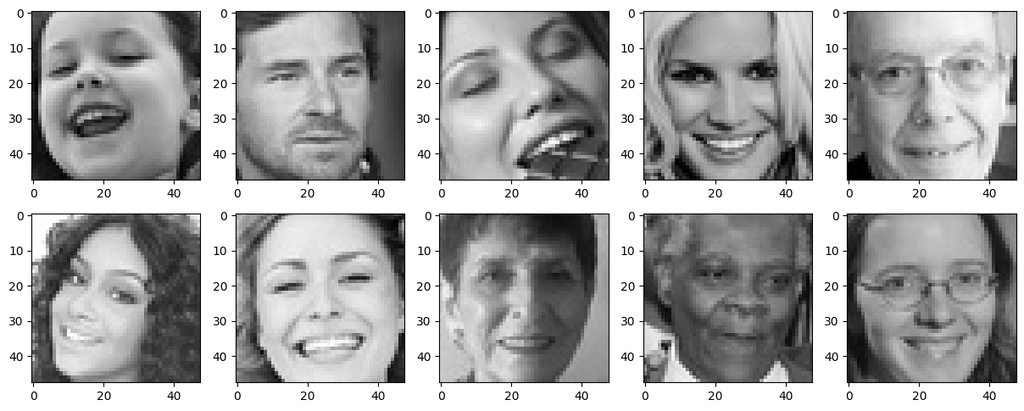

```python
plt.figure(figsize=(15, 15))

for i in range(1, 11):
    plt.subplot(5, 5, i)

    img = load_img(folder_path + '/train/happy/' + os.listdir('/content/Facial_emotion_images/train/happy/')[i], target_size=(image_size, image_size))
    plt.imshow(img)

plt.show()
```

**Observations and Insights:** While a smile is generally a good indicator of happiness, not all pictures labelled happy have the person smiling, or some smiles may not be as obvious. Other features that can indicate happiness are cheeks raised, wrinkles around eyes and more prominent nasolabial folds. While there is a picture of someone eating chocolate, this may not be common in the entire set, and is also likely to be included in pictures of people who are sad as well.

### **Sad**

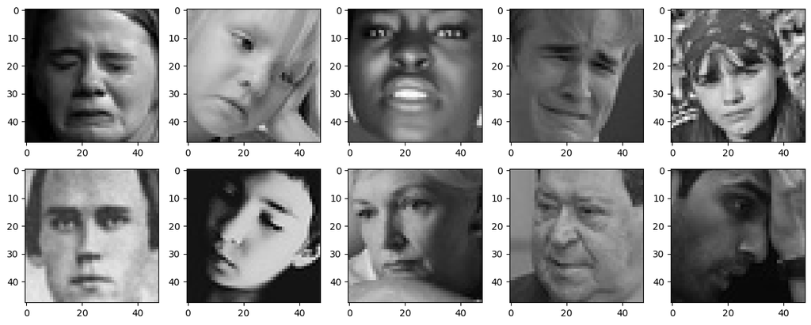

```python
plt.figure(figsize=(15, 15))

for i in range(1, 11):
    plt.subplot(5, 5, i)

    img = load_img(folder_path + '/train/sad/' + os.listdir('/content/Facial_emotion_images/train/sad/')[i], target_size=(image_size, image_size))
    plt.imshow(img)

plt.show()
```

**Observations and Insights:** For sad, people are generally frowning or crying/have scrunched up eyes and furrowed brows. In some photos people have one hand somewhere in the picture, either on their forehead or side of their face. While not always the case, in general it seems that peoples teeth aren't usually visible in pictures where they are sad.

### **Neutral**

[figure not shown]

```python
plt.figure(figsize=(15, 15))

for i in range(11, 21):
    plt.subplot(5, 5, i)

    img = load_img(folder_path + '/train/neutral/' + os.listdir('/content/Facial_emotion_images/train/neutral/')[i], target_size=(image_size, image_size))
    plt.imshow(img)

plt.show()
```

**Observations and Insights:** For neutral, in general peoples facial features are all relaxed, so not smiling or frowning and not raising eyebrows or furrowing eyebrows. They don't generally show their teeth and their hands don't appear to be in the picture much compared to sad/surprised.

### **Surprised**

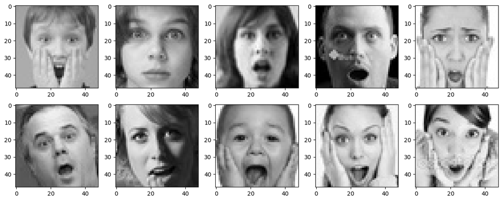

```python
plt.figure(figsize=(15, 15))

for i in range(1, 11):
    plt.subplot(5, 5, i)

    img = load_img(folder_path + '/train/surprise/' + os.listdir('/content/Facial_emotion_images/train/surprise/')[i], target_size=(image_size, image_size))
    plt.imshow(img)

plt.show()
```

**Observations and Insights:** The most obvious signs for suprised are a wide open mouth, big eyes, raised eyebrows and sometimes with their hands on both sides of their face.

## **Checking Distribution of Classes**

```
Number of images in class happy: 3976
Number of images in class sad: 3982
Number of images in class neutral: 3978
Number of images in class surprised: 3173
```

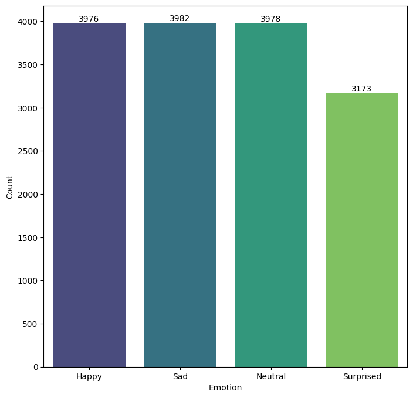

```python
# Count how many images of each type are in the training set.
num_happy = len(os.listdir(folder_path + '/train/happy'))
print('Number of images in class happy:', num_happy)

num_sad = len(os.listdir(folder_path + '/train/sad'))
print('Number of images in class sad:', num_sad)

num_neutral = len(os.listdir(folder_path + '/train/neutral'))
print('Number of images in class neutral:', num_neutral)

num_surprised = len(os.listdir(folder_path + '/train/surprise'))
print('Number of images in class surprised:', num_surprised)

# Create DataFrame of the data
data = {'Emotion': ['Happy', 'Sad', 'Neutral', 'Surprised'],
        'Count': [num_happy, num_sad, num_neutral, num_surprised]}

df = pd.DataFrame(data)

# Plot a bar graph of the number of images in each class
plt.figure(figsize=(8, 8))

sns.barplot(x='Emotion', y='Count', data=df, palette='viridis')

for index, value in enumerate(df['Count']):
    plt.text(index, value + 0.1, str(value), ha='center', va='bottom')

plt.show()
```

**Observations and Insights:** The amount of images in happy, sad and neutral are almost the same, but there are about 3/4 of images for the surprised class. This could potentially lead to poor generalization in the model. If this turns out to be the case, we can augment the data to balance the classes out.

**Think About It:**

- Are the classes equally distributed? If not, do you think the imbalance is too high? Will it be a problem as we progress?
- Are there any Exploratory Data Analysis tasks that we can do here? Would they provide any meaningful insights?

## **Creating our Data Loaders**

In this section, we are creating data loaders that we will use as inputs to our Neural Network.

**You have two options for the color_mode. You can set it to color_mode = 'rgb' or color_mode = 'grayscale'. You will need to try out both and see for yourself which one gives better performance.**

```python
batch_size  = 32

# Creating data generators for train, validation and test set with color_mode = 'rgb'
datagen_train = ImageDataGenerator(horizontal_flip = True,
                                    brightness_range=(0.,2.),
                                    rescale=1./255,
                                    shear_range=0.3)

train_set = datagen_train.flow_from_directory('Facial_emotion_images/train',
                                              target_size = (image_size, image_size),
                                              color_mode = 'rgb',
                                              batch_size = batch_size,
                                              class_mode = 'categorical',
                                              shuffle = True)

datagen_validation = ImageDataGenerator(horizontal_flip = True,
                                    brightness_range=(0.,2.),
                                    rescale=1./255,
                                    shear_range=0.3)

validation_set = datagen_validation.flow_from_directory('Facial_emotion_images/validation',
                                              target_size = (image_size, image_size),
                                              color_mode = 'rgb',
                                              batch_size = batch_size,
                                              class_mode = 'categorical',
                                              shuffle = True)

datagen_test = ImageDataGenerator(horizontal_flip = True,
                                    brightness_range=(0.,2.),
                                    rescale=1./255,
                                    shear_range=0.3)

test_set = datagen_test.flow_from_directory('Facial_emotion_images/test',
                                              target_size = (image_size, image_size),
                                              color_mode = 'rgb',
                                              batch_size = batch_size,
                                              class_mode = 'categorical',
                                              shuffle = True)
```

```
Found 15109 images belonging to 4 classes.
Found 4977 images belonging to 4 classes.
Found 128 images belonging to 4 classes.
```

```python
# Creating data generators for train, validation and test set with color_mode = 'grayscale'
datagen_train_gray = ImageDataGenerator(horizontal_flip = True,
                                    brightness_range=(0.,2.),
                                    rescale=1./255,
                                    shear_range=0.3)

train_set_gray = datagen_train_gray.flow_from_directory('Facial_emotion_images/train',
                                              target_size = (image_size, image_size),
                                              color_mode = 'grayscale',
                                              batch_size = batch_size,
                                              class_mode = 'categorical',
                                              shuffle = True)

datagen_validation_gray = ImageDataGenerator(horizontal_flip = True,
                                    brightness_range=(0.,2.),
                                    rescale=1./255,
                                    shear_range=0.3)

validation_set_gray = datagen_validation_gray.flow_from_directory('Facial_emotion_images/validation',
                                              target_size = (image_size, image_size),
                                              color_mode = 'grayscale',
                                              batch_size = batch_size,
                                              class_mode = 'categorical',
                                              shuffle = True)

datagen_test_gray = ImageDataGenerator(horizontal_flip = True,
                                    brightness_range=(0.,2.),
                                    rescale=1./255,
                                    shear_range=0.3)

test_set_gray = datagen_test_gray.flow_from_directory('Facial_emotion_images/test',
                                              target_size = (image_size, image_size),
                                              color_mode = 'grayscale',
                                              batch_size = batch_size,
                                              class_mode = 'categorical',
                                              shuffle = True)
```

```
Found 15109 images belonging to 4 classes.
Found 4977 images belonging to 4 classes.
Found 128 images belonging to 4 classes.
```

## **Model Building**

**Think About It:**

- Are Convolutional Neural Networks the right approach? Should we have gone with Artificial Neural Networks instead?
- What are the advantages of CNNs over ANNs and are they applicable here?

### **Creating the Base Neural Network**

```python
# Fixing the seed
random.seed(42)
np.random.seed(42)
tf.random.set_seed(42)
```

```python
# Input shape with of image_size x image_size, and 3 channels for rgb
input_shape=(image_size, image_size, 3)
num_classes=4

# Save the best model in model1.h5
checkpoint = ModelCheckpoint("./model1.h5", monitor='val_accuracy', verbose=1, save_best_only=True, mode='max')

# Stop early if loss function doesn't improve
early_stopping = EarlyStopping(monitor = 'val_loss',
                          min_delta = 0,
                          patience = 3,
                          verbose = 1,
                          restore_best_weights = True
                          )

# Reduce learning rate if loss starts to plateau
reduce_learningrate = ReduceLROnPlateau(monitor = 'val_loss',
                              factor = 0.2,
                              patience = 3,
                              verbose = 1,
                              min_delta = 0.0001)

callbacks_list = [early_stopping, checkpoint, reduce_learningrate]

# Define the model
def cnn_model_1(input_shape=input_shape, num_classes=num_classes):
    # Initialize the model
    model = Sequential()

    # First Conv block
    model.add(Conv2D(64, (2, 2), padding='same', activation='relu', input_shape=input_shape))
    model.add(MaxPooling2D(pool_size=(2, 2)))
    model.add(Dropout(0.2))

    # Second Convolutional Block
    model.add(Conv2D(32, (2, 2), padding='same', activation='relu'))
    model.add(MaxPooling2D(pool_size=(2, 2)))
    model.add(Dropout(0.2))

    # Third Convolutional Block
    model.add(Conv2D(32, (2, 2), padding='same', activation='relu'))
    model.add(MaxPooling2D(pool_size=(2, 2)))
    model.add(Dropout(0.2))

    # Flatten layer
    model.add(Flatten())

    # Dense layers
    model.add(Dense(512, activation='relu'))
    model.add(Dropout(0.4))
    model.add(Dense(256, activation='relu'))
    model.add(Dense(4, activation='softmax'))

    # Compile the model
    model.compile(optimizer=Adam(learning_rate=0.001),
                  loss='categorical_crossentropy',
                  metrics=['accuracy'])

    return model
```

```python
model1 = cnn_model_1()

model1.summary()
```

```
Model: "sequential"
_________________________________________________________________
 Layer (type)                Output Shape              Param #
=================================================================
 conv2d (Conv2D)             (None, 48, 48, 64)        832

 max_pooling2d (MaxPooling2  (None, 24, 24, 64)        0
 D)

 dropout (Dropout)           (None, 24, 24, 64)        0

 conv2d_1 (Conv2D)           (None, 24, 24, 32)        8224

 max_pooling2d_1 (MaxPoolin  (None, 12, 12, 32)        0
 g2D)

 dropout_1 (Dropout)         (None, 12, 12, 32)        0

 conv2d_2 (Conv2D)           (None, 12, 12, 32)        4128

 max_pooling2d_2 (MaxPoolin  (None, 6, 6, 32)          0
 g2D)

 dropout_2 (Dropout)         (None, 6, 6, 32)          0

 flatten (Flatten)           (None, 1152)              0

 dense (Dense)               (None, 512)               590336

 dropout_3 (Dropout)         (None, 512)               0

 dense_1 (Dense)             (None, 256)               131328

 dense_2 (Dense)             (None, 4)                 1028

=================================================================
Total params: 735876 (2.81 MB)
Trainable params: 735876 (2.81 MB)
Non-trainable params: 0 (0.00 Byte)
_________________________________________________________________
```

```python
history = model1.fit(train_set,
                    epochs=20,
                    validation_data=validation_set,
                    callbacks=callbacks_list)
```

```
Epoch 1: val_accuracy improved from -inf to 0.46253, saving model to ./model1.h5
```

```
Epoch 2: val_accuracy improved from 0.46253 to 0.52080, saving model to ./model1.h5
Epoch 3: val_accuracy improved from 0.52080 to 0.56018, saving model to ./model1.h5
Epoch 4: val_accuracy improved from 0.56018 to 0.57565, saving model to ./model1.h5
Epoch 5: val_accuracy improved from 0.57565 to 0.59373, saving model to ./model1.h5
Epoch 6: val_accuracy improved from 0.59373 to 0.59936, saving model to ./model1.h5
Epoch 7: val_accuracy improved from 0.59936 to 0.62447, saving model to ./model1.h5
Epoch 8: val_accuracy improved from 0.62447 to 0.63593, saving model to ./model1.h5
Epoch 9: val_accuracy did not improve from 0.63593
Epoch 10: val_accuracy did not improve from 0.63593
Epoch 11: val_accuracy did not improve from 0.63593
Epoch 12: val_accuracy improved from 0.63593 to 0.64175, saving model to ./model1.h5
Epoch 13: val_accuracy improved from 0.64175 to 0.64436, saving model to ./model1.h5
Epoch 14: val_accuracy did not improve from 0.64436
Epoch 15: val_accuracy improved from 0.64436 to 0.65642, saving model to ./model1.h5
Epoch 16: val_accuracy did not improve from 0.65642
Epoch 17: val_accuracy improved from 0.65642 to 0.65682, saving model to ./model1.h5
Epoch 18: val_accuracy improved from 0.65682 to 0.65883, saving model to ./model1.h5
Epoch 19: val_accuracy improved from 0.65883 to 0.65923, saving model to ./model1.h5
Epoch 20: val_accuracy improved from 0.65923 to 0.66787, saving model to ./model1.h5
```

```python
# Clear backend
backend.clear_session()

# Fixing the seed after clearing backend
random.seed(42)
np.random.seed(42)
tf.random.set_seed(42)
```

```python
# Change number of channels to 1 for grayscale
input_shape=(image_size, image_size, 1)
model1_gray = cnn_model_1(input_shape)

model1_gray.summary()
```

```
Model: "sequential"
_________________________________________________________________
 Layer (type)                Output Shape              Param #
=================================================================
 conv2d (Conv2D)             (None, 48, 48, 64)        320

 max_pooling2d (MaxPooling2  (None, 24, 24, 64)        0
 D)

 dropout (Dropout)           (None, 24, 24, 64)        0

 conv2d_1 (Conv2D)           (None, 24, 24, 32)        8224

 max_pooling2d_1 (MaxPoolin  (None, 12, 12, 32)        0
 g2D)

 dropout_1 (Dropout)         (None, 12, 12, 32)        0

 conv2d_2 (Conv2D)           (None, 12, 12, 32)        4128

 max_pooling2d_2 (MaxPoolin  (None, 6, 6, 32)          0
 g2D)

 dropout_2 (Dropout)         (None, 6, 6, 32)          0

 flatten (Flatten)           (None, 1152)              0

 dense (Dense)               (None, 512)               590336

 dropout_3 (Dropout)         (None, 512)               0

 dense_1 (Dense)             (None, 256)               131328

 dense_2 (Dense)             (None, 4)                 1028

=================================================================
Total params: 735364 (2.81 MB)
Trainable params: 735364 (2.81 MB)
Non-trainable params: 0 (0.00 Byte)
_________________________________________________________________
```

```python
# Save best model as ./model2.h5
checkpoint = ModelCheckpoint("./model2.h5", monitor='val_accuracy', verbose=1, save_best_only=True, mode='max')
callbacks_list = [early_stopping, checkpoint, reduce_learningrate]

history1 = model1_gray.fit(train_set_gray,
                    epochs=20,
                    validation_data=validation_set_gray,
                    callbacks=callbacks_list)
```

```
Epoch 1: val_accuracy improved from -inf to 0.44384, saving model to ./model2.h5
Epoch 2: val_accuracy improved from 0.44384 to 0.52923, saving model to ./model2.h5
Epoch 3: val_accuracy improved from 0.52923 to 0.54029, saving model to ./model2.h5
Epoch 4: val_accuracy improved from 0.54029 to 0.57083, saving model to ./model2.h5
Epoch 5: val_accuracy improved from 0.57083 to 0.59554, saving model to ./model2.h5
Epoch 6: val_accuracy did not improve from 0.59554
Epoch 7: val_accuracy improved from 0.59554 to 0.60619, saving model to ./model2.h5
Epoch 8: val_accuracy did not improve from 0.60619
Epoch 9: val_accuracy improved from 0.60619 to 0.62086, saving model to ./model2.h5
Epoch 10: val_accuracy did not improve from 0.62086
Epoch 11: val_accuracy improved from 0.62086 to 0.62990, saving model to ./model2.h5
Epoch 12: val_accuracy did not improve from 0.62990
Epoch 13: val_accuracy improved from 0.62990 to 0.63030, saving model to ./model2.h5
Epoch 14: val_accuracy did not improve from 0.63030
Epoch 15: val_accuracy improved from 0.63030 to 0.64537, saving model to ./model2.h5
Epoch 16: val_accuracy improved from 0.64537 to 0.64959, saving model to ./model2.h5
Epoch 17: val_accuracy did not improve from 0.64959
Epoch 18: val_accuracy did not improve from 0.64959
Epoch 19: val_accuracy improved from 0.64959 to 0.66104, saving model to ./model2.h5
Epoch 20: val_accuracy did not improve from 0.66104
```

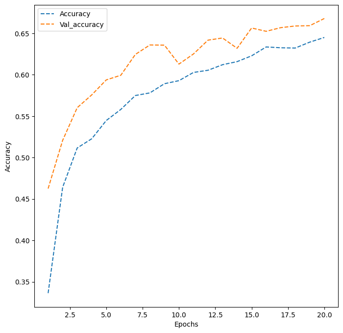

```python
# Plotting training and validation accuracies
dict_hist = history.history
list_epochs = [i for i in range(1, 21)]

plt.figure(figsize=(8, 8))

plt.plot(list_epochs, dict_hist['accuracy'], ls='--', label='Accuracy')
plt.plot(list_epochs, dict_hist['val_accuracy'], ls='--', label='Val_accuracy')

plt.xlabel('Epochs')
plt.ylabel('Accuracy')

plt.legend()
plt.show()
```

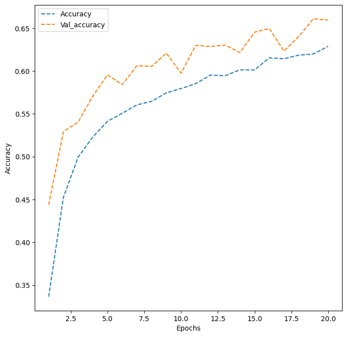

```python
# Plot training and validation accuracies
dict_hist1 = history1.history

plt.figure(figsize=(8, 8))

plt.plot(list_epochs, dict_hist1['accuracy'], ls='--', label='Accuracy')
plt.plot(list_epochs, dict_hist1['val_accuracy'], ls='--', label='Val_accuracy')

plt.xlabel('Epochs')
plt.ylabel('Accuracy')

plt.legend()
plt.show()
```

**Observations:** The accuracy values are roughly the same using both 'rgb' and 'grayscale'. The validation and training accuracy aren't too different from each other, suggesting that neither model is overfitting.

### **Evaluating the Model on the Test Set**

```python
# Get next set of images and labels from test set
test_images, test_labels = next(test_set)
```

```python
accuracy1 = model1.evaluate(test_images, test_labels, verbose=2)
```

```
1/1 - 0s - loss: 0.8332 - accuracy: 0.7188 - 40ms/epoch - 40ms/step
```

```
              precision    recall  f1-score   support

           0       0.75      0.60      0.67         5
           1       0.75      0.90      0.82        10
           2       0.67      0.67      0.67         9
           3       0.71      0.62      0.67         8

    accuracy                           0.72        32
   macro avg       0.72      0.70      0.70        32
weighted avg       0.72      0.72      0.71        32
```

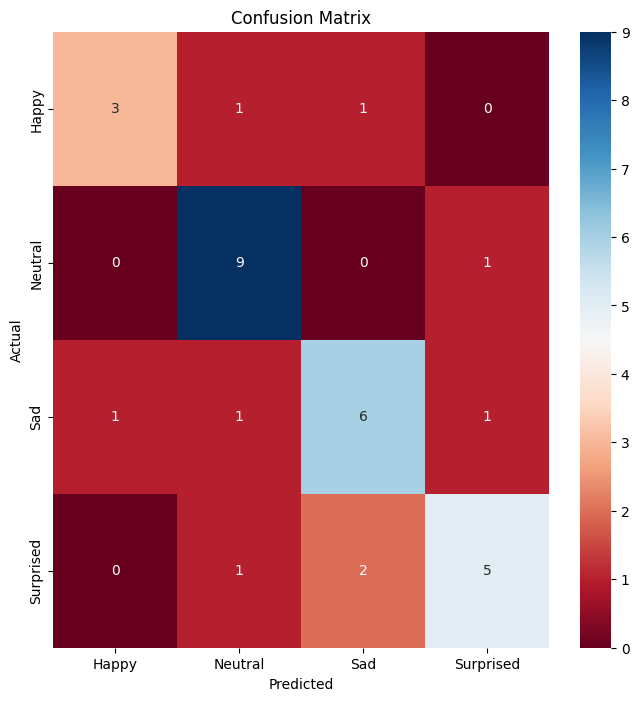

```python
pred = model1.predict(test_images)

# Turn predicted values into single values
pred = np.argmax(pred, axis=1)
y_true = np.argmax(test_labels, axis=1)

# Print classification report
print(classification_report(y_true, pred))

cm = confusion_matrix(y_true, pred)

# Get class labels
classes = ['Happy', 'Neutral', 'Sad', 'Surprised']

# Plot the heatmap
plt.figure(figsize=(8, 8))
sns.heatmap(cm, annot=True, fmt='.0f', xticklabels=classes, yticklabels=classes, cmap='RdBu')

# Set labels and title
plt.xlabel('Predicted')
plt.ylabel('Actual')
plt.title('Confusion Matrix')

# Show the plot
plt.show()
```

**Observations and Insights:** The accuracy on the test data is 72%. The f1 scores for happy, sad and surprised are all 0.67, whereas it's 0.82 for neutral, which is also the most common class in the test set. This, paired with a small amount of data in the test set is the most likely cause of the test data outperforming the training data.

### **Creating the second Convolutional Neural Network**

- Try out a slightly larger architecture

```python
# Clear backend
backend.clear_session()

# Fixing the seed after clearing backend
random.seed(42)
np.random.seed(42)
tf.random.set_seed(42)
```

```python
# Set input_shape with 3 channels for rgb and set up callbacks.
input_shape = (input_shape, input_shape, 3)

checkpoint = ModelCheckpoint("./model3.h5", monitor='val_accuracy', verbose=1, save_best_only=True, mode='max')

early_stopping = EarlyStopping(monitor = 'val_loss',
                          min_delta = 0,
                          patience = 3,
                          verbose = 1,
                          restore_best_weights = True
                          )

reduce_learningrate = ReduceLROnPlateau(monitor = 'val_loss',
                              factor = 0.2,
                              patience = 3,
                              verbose = 1,
                              min_delta = 0.0001)

callbacks_list = [early_stopping, checkpoint, reduce_learningrate]


def cnn_model_2(input_shape=input_shape, num_classes=num_classes):
    # Initialize the CNN
    model = Sequential()

    # First Convolutional Block
    model.add(Conv2D(128, (2, 2), padding='same', activation='relu', input_shape=input_shape))
    model.add(BatchNormalization())
    model.add(LeakyReLU(alpha=0.1))
    model.add(MaxPooling2D(pool_size=(2, 2)))

    # Second Convolutional Block
    model.add(Conv2D(64, (2, 2), padding='same', activation='relu'))
    model.add(BatchNormalization())
    model.add(LeakyReLU(alpha=0.1))
    model.add(MaxPooling2D(pool_size=(2, 2)))

    # Third Convolutional Block
    model.add(Conv2D(64, (2, 2), padding='same', activation='relu'))
    model.add(BatchNormalization())
    model.add(LeakyReLU(alpha=0.1))
    model.add(MaxPooling2D(pool_size=(2, 2)))

    # Fourth Convolutional Block
    model.add(Conv2D(32, (2, 2), padding='same', activation='relu'))
    model.add(BatchNormalization())
    model.add(LeakyReLU(alpha=0.1))
    model.add(MaxPooling2D(pool_size=(2, 2)))

    # Flatten layer
    model.add(Flatten())

    # Dense layers
    model.add(Dense(512, activation='relu'))
    model.add(Dense(4, activation='softmax'))

    model.compile(optimizer=Adam(learning_rate=0.001),
                  loss='categorical_crossentropy',
                  metrics=['accuracy'])

    return model
```

### **Compiling and Training the Model**

```python
model3 = cnn_model_2()

model3.summary()
```

```
Model: "sequential"
_________________________________________________________________
 Layer (type)                Output Shape              Param #
=================================================================
 conv2d (Conv2D)             (None, 48, 48, 128)       1664

 batch_normalization (Batch  (None, 48, 48, 128)       512
 Normalization)

 leaky_re_lu (LeakyReLU)     (None, 48, 48, 128)       0

 max_pooling2d (MaxPooling2  (None, 24, 24, 128)       0
 D)

 conv2d_1 (Conv2D)           (None, 24, 24, 64)        32832

 batch_normalization_1 (Bat  (None, 24, 24, 64)        256
 chNormalization)

 leaky_re_lu_1 (LeakyReLU)   (None, 24, 24, 64)        0

 max_pooling2d_1 (MaxPoolin  (None, 12, 12, 64)        0
 g2D)

 conv2d_2 (Conv2D)           (None, 12, 12, 64)        16448

 batch_normalization_2 (Bat  (None, 12, 12, 64)        256
 chNormalization)

 leaky_re_lu_2 (LeakyReLU)   (None, 12, 12, 64)        0

 max_pooling2d_2 (MaxPoolin  (None, 6, 6, 64)          0
 g2D)

 conv2d_3 (Conv2D)           (None, 6, 6, 32)          8224

 batch_normalization_3 (Bat  (None, 6, 6, 32)          128
 chNormalization)

 leaky_re_lu_3 (LeakyReLU)   (None, 6, 6, 32)          0

 max_pooling2d_3 (MaxPoolin  (None, 3, 3, 32)          0
 g2D)

 flatten (Flatten)           (None, 288)               0

 dense (Dense)               (None, 512)               147968

 dense_1 (Dense)             (None, 4)                 2052

=================================================================
Total params: 210340 (821.64 KB)
Trainable params: 209764 (819.39 KB)
Non-trainable params: 576 (2.25 KB)
_________________________________________________________________
```

```python
history2 = model3.fit(train_set,
                     epochs=20,
                     validation_data=validation_set,
                     callbacks=callbacks_list)
```

```
Epoch 1: val_accuracy improved from -inf to 0.43239, saving model to ./model3.h5
```

```
Epoch 2: val_accuracy improved from 0.43239 to 0.48302, saving model to ./model3.h5
Epoch 3: val_accuracy improved from 0.48302 to 0.53084, saving model to ./model3.h5
Epoch 4: val_accuracy improved from 0.53084 to 0.60719, saving model to ./model3.h5
Epoch 5: val_accuracy improved from 0.60719 to 0.62608, saving model to ./model3.h5
Epoch 6: val_accuracy did not improve from 0.62608
Epoch 7: val_accuracy improved from 0.62608 to 0.64497, saving model to ./model3.h5
Epoch 8: val_accuracy improved from 0.64497 to 0.67129, saving model to ./model3.h5
Epoch 9: val_accuracy did not improve from 0.67129
Epoch 10: val_accuracy improved from 0.67129 to 0.68455, saving model to ./model3.h5
Epoch 11: val_accuracy did not improve from 0.68455
Epoch 12: val_accuracy did not improve from 0.68455
Epoch 13: val_accuracy did not improve from 0.68455
Epoch 14: val_accuracy did not improve from 0.68455

Epoch 15: val_accuracy did not improve from 0.68455

Epoch 15: ReduceLROnPlateau reducing learning rate to 0.00020000000949949026.
Epoch 15: early stopping
```

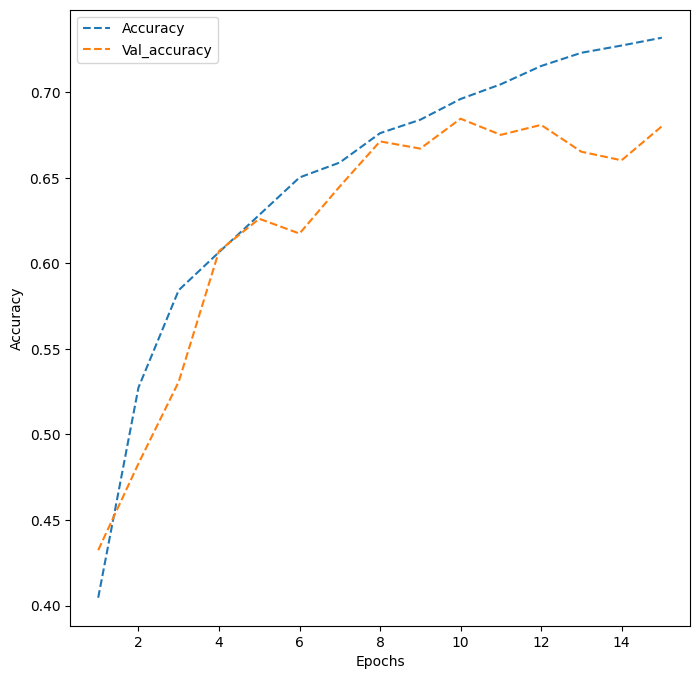

```python
# Plot training and validation accuracies
dict_hist2 = history2.history
list_epochs = [i for i in range(1, 16)]

plt.figure(figsize=(8, 8))

plt.plot(list_epochs, dict_hist2['accuracy'], ls='--', label='Accuracy')
plt.plot(list_epochs, dict_hist2['val_accuracy'], ls='--', label='Val_accuracy')

plt.xlabel('Epochs')
plt.ylabel('Accuracy')

plt.legend()
plt.show()
```

**Observations:** The training accuracy is higher for this model, however the gap between training and validation accuracies is wider, hence the model is most likely overfitting. Adding Dropout layers to the network would be a good choice to reduce overfitting.

### **Evaluating the Model on the Test Set**

```python
# Print accuracy of second CNN
accuracy2 = model3.evaluate(test_images, test_labels, verbose=2)
```

```
1/1 - 0s - loss: 0.6765 - accuracy: 0.6875 - 188ms/epoch - 188ms/step
```

```
              precision    recall  f1-score   support

           0       0.60      0.60      0.60         5
           1       0.64      0.90      0.75        10
           2       0.71      0.56      0.63         9
           3       0.83      0.62      0.71         8

    accuracy                           0.69        32
   macro avg       0.70      0.67      0.67        32
weighted avg       0.70      0.69      0.68        32
```

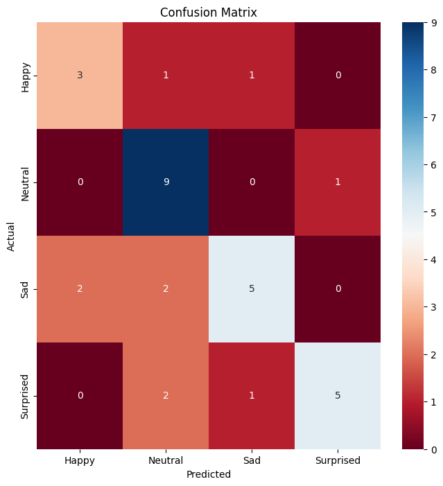

```python
pred = model3.predict(test_images)

# Turn predicted values into single values
pred = np.argmax(pred, axis=1)
y_true = np.argmax(test_labels, axis=1)

# Print classification report
print(classification_report(y_true, pred))

cm = confusion_matrix(y_true, pred)

# Get class labels
classes = ['Happy', 'Neutral', 'Sad', 'Surprised']

# Plot the heatmap
plt.figure(figsize=(8, 8))
sns.heatmap(cm, annot=True, fmt='.0f', xticklabels=classes, yticklabels=classes, cmap='RdBu')

# Set labels and title
plt.xlabel('Predicted')
plt.ylabel('Actual')
plt.title('Confusion Matrix')

# Show the plot
plt.show()
```

**Observations and Insights:** Compared to the previous model on the same test set, the test accuracy is worse even though the training accuracy was higher, so that helps show that the model is most likely overfitting to the data. Once again the neutral class has the highest f1-score.

## **Think About It:**

- Did the models have a satisfactory performance? If not, then what are the possible reasons?
- Which Color mode showed better overall performance? What are the possible reasons? Do you think having 'rgb' color mode is needed because the images are already black and white?

## **Transfer Learning Architectures**

In this section, we will create several Transfer Learning architectures. For the pre-trained models, we will select three popular architectures namely, VGG16, ResNet v2, and Efficient Net. The difference between these architectures and the previous architectures is that these will require 3 input channels while the earlier ones worked on 'grayscale' images. Therefore, we need to create new DataLoaders.

### **Creating our Data Loaders for Transfer Learning Architectures**

In this section, we are creating data loaders that we will use as inputs to our Neural Network. We will have to go with color_mode = 'rgb' as this is the required format for the transfer learning architectures.

```python
batch_size  = 32

# Creating data generators for train, validation and test set with color_mode = 'rgb'
datagen_train = ImageDataGenerator(horizontal_flip = True,
                                    brightness_range=(0.,2.),
                                    rescale=1./255,
                                    shear_range=0.3)

train_set = datagen_train.flow_from_directory('Facial_emotion_images/train',
                                              target_size = (image_size, image_size),
                                              color_mode = 'rgb',
                                              batch_size = batch_size,
                                              class_mode = 'categorical',
                                              shuffle = True)

datagen_validation = ImageDataGenerator(horizontal_flip = True,
                                    brightness_range=(0.,2.),
                                    rescale=1./255,
                                    shear_range=0.3)

validation_set = datagen_validation.flow_from_directory('Facial_emotion_images/validation',
                                              target_size = (image_size, image_size),
                                              color_mode = 'rgb',
                                              batch_size = batch_size,
                                              class_mode = 'categorical',
                                              shuffle = True)

datagen_test = ImageDataGenerator(horizontal_flip = True,
                                    brightness_range=(0.,2.),
                                    rescale=1./255,
                                    shear_range=0.3)

test_set = datagen_test.flow_from_directory('Facial_emotion_images/test',
                                              target_size = (image_size, image_size),
                                              color_mode = 'rgb',
                                              batch_size = batch_size,
                                              class_mode = 'categorical',
                                              shuffle = True)
```

```
Found 15109 images belonging to 4 classes.
Found 4977 images belonging to 4 classes.
Found 128 images belonging to 4 classes.
```

## **VGG16 Model**

### **Importing the VGG16 Architecture**

```python
# Clear backend
backend.clear_session()

# Fixing the seed after clearing backend
random.seed(42)
np.random.seed(42)
tf.random.set_seed(42)
```

```python
from tensorflow.keras.applications.vgg16 import VGG16
from tensorflow.keras import Model

# Import CNN part of VGG16 architecture and weights from imagenet
vgg = VGG16(include_top = False, weights = 'imagenet', input_shape = (48, 48, 3))
vgg.summary()
```

```
WARNING:tensorflow:From C:\Users\david.bunyan\AppData\Local\Packages\PythonSoftwareFoundation.Python.3.11_qbz5n2kfra8p0\LocalCache\local-packages\Python311\site-packages\keras\src\backend.py:1398: The name tf.executing_eagerly_outside_functions is deprecated. Please use tf.compat.v1.executing_eagerl…

WARNING:tensorflow:From C:\Users\david.bunyan\AppData\Local\Packages\PythonSoftwareFoundation.Python.3.11_qbz5n2kfra8p0\LocalCache\local-packages\Python311\site-packages\keras\src\layers\pooling\max_pooling2d.py:161: The name tf.nn.max_pool is deprecated. Please use tf.nn.max_pool2d instead.

Model: "vgg16"
_________________________________________________________________
 Layer (type)                Output Shape              Param #
=================================================================
 input_1 (InputLayer)        [(None, 48, 48, 3)]       0

 block1_conv1 (Conv2D)       (None, 48, 48, 64)        1792

 block1_conv2 (Conv2D)       (None, 48, 48, 64)        36928

 block1_pool (MaxPooling2D)  (None, 24, 24, 64)        0

 block2_conv1 (Conv2D)       (None, 24, 24, 128)       73856

 block2_conv2 (Conv2D)       (None, 24, 24, 128)       147584

 block2_pool (MaxPooling2D)  (None, 12, 12, 128)       0

 block3_conv1 (Conv2D)       (None, 12, 12, 256)       295168

 block3_conv2 (Conv2D)       (None, 12, 12, 256)       590080

 block3_conv3 (Conv2D)       (None, 12, 12, 256)       590080

 block3_pool (MaxPooling2D)  (None, 6, 6, 256)         0

 block4_conv1 (Conv2D)       (None, 6, 6, 512)         1180160

 block4_conv2 (Conv2D)       (None, 6, 6, 512)         2359808

 block4_conv3 (Conv2D)       (None, 6, 6, 512)         2359808

 block4_pool (MaxPooling2D)  (None, 3, 3, 512)         0

 block5_conv1 (Conv2D)       (None, 3, 3, 512)         2359808

 block5_conv2 (Conv2D)       (None, 3, 3, 512)         2359808

 block5_conv3 (Conv2D)       (None, 3, 3, 512)         2359808

 block5_pool (MaxPooling2D)  (None, 1, 1, 512)         0

=================================================================
Total params: 14714688 (56.13 MB)
Trainable params: 14714688 (56.13 MB)
Non-trainable params: 0 (0.00 Byte)
_________________________________________________________________
```

### **Model Building**

- Import VGG16 upto the layer of your choice and add Fully Connected layers on top of it.

```python
# Copy up to the pooling layer of the third block
transfer_layer = vgg.get_layer('block3_pool')

# Set the weights to not be trained
vgg.trainable = False

# Flattenning the output from the 3rd block of the VGG16 model
x = Flatten()(transfer_layer.output)

# Adding a Dense layer with 256 neurons
x = Dense(256, activation = 'relu')(x)

# Adding a Dense Layer with 128 neurons
x = Dense(128, activation='relu')(x)

# Adding a Dropout layer with Dropout ratio of 0.3
x = Dropout(0.3)(x)

# Add a Dense Layer with 64 neurons
x = Dense(64, activation='relu')(x)

# Add a Batch Normalization layer
x = BatchNormalization()(x)

# Adding the final dense layer with 4 neurons and using 'softmax' activation
pred = Dense(4, activation='softmax')(x)

# Initializing the model
vggmodel = Model(vgg.input, pred)
```

### **Compiling and Training the VGG16 Model**

```python
checkpoint = ModelCheckpoint("./vggmodel.h5", monitor = 'val_loss', verbose = 1, save_best_only = True, mode = 'max')

callbacks_list = [early_stopping, checkpoint, reduce_learningrate]
```

```python
# Compile the model
vggmodel.compile(optimizer=Adam(learning_rate=0.001),
                 loss='categorical_crossentropy',
                 metrics=['accuracy'])

vggmodel.summary()
```

```
Model: "model_1"
_________________________________________________________________
 Layer (type)                Output Shape              Param #
=================================================================
 input_1 (InputLayer)        [(None, 48, 48, 3)]       0

 block1_conv1 (Conv2D)       (None, 48, 48, 64)        1792

 block1_conv2 (Conv2D)       (None, 48, 48, 64)        36928

 block1_pool (MaxPooling2D)  (None, 24, 24, 64)        0

 block2_conv1 (Conv2D)       (None, 24, 24, 128)       73856

 block2_conv2 (Conv2D)       (None, 24, 24, 128)       147584

 block2_pool (MaxPooling2D)  (None, 12, 12, 128)       0

 block3_conv1 (Conv2D)       (None, 12, 12, 256)       295168

 block3_conv2 (Conv2D)       (None, 12, 12, 256)       590080

 block3_conv3 (Conv2D)       (None, 12, 12, 256)       590080

 block3_pool (MaxPooling2D)  (None, 6, 6, 256)         0

 flatten_1 (Flatten)         (None, 9216)              0

 dense_4 (Dense)             (None, 256)               2359552

 dense_5 (Dense)             (None, 128)               32896

 dropout_1 (Dropout)         (None, 128)               0

 dense_6 (Dense)             (None, 64)                8256

 batch_normalization_1 (Bat  (None, 64)                256
 chNormalization)

 dense_7 (Dense)             (None, 4)                 260

=================================================================
Total params: 4136708 (15.78 MB)
Trainable params: 2401092 (9.16 MB)
Non-trainable params: 1735616 (6.62 MB)
_________________________________________________________________
```

```python
vggmodel.fit(train_set, epochs=20, batch_size=batch_size, validation_data=validation_set)
```

```
<keras.src.callbacks.History at 0x7c856bf1cdf0>
```

### **Evaluating the VGG16 model**

```python
accuracy_vgg = vggmodel.evaluate(test_images, test_labels, verbose=2)
```

```
1/1 - 2s - loss: 0.7762 - accuracy: 0.6875 - 2s/epoch - 2s/step
```

```
              precision    recall  f1-score   support

           0       0.75      0.60      0.67         5
           1       0.56      1.00      0.71        10
           2       0.83      0.56      0.67         9
           3       1.00      0.50      0.67         8

    accuracy                           0.69        32
   macro avg       0.78      0.66      0.68        32
weighted avg       0.78      0.69      0.68        32
```

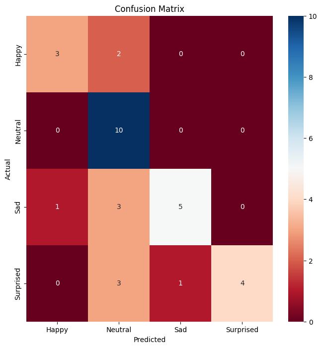

```python
pred = vggmodel.predict(test_images)

# Turn predicted values into single values
pred = np.argmax(pred, axis=1)
y_true = np.argmax(test_labels, axis=1)

# Print classification report
print(classification_report(y_true, pred))

cm = confusion_matrix(y_true, pred)

# Get class labels
classes = ['Happy', 'Neutral', 'Sad', 'Surprised']

# Plot the heatmap
plt.figure(figsize=(8, 8))
sns.heatmap(cm, annot=True, fmt='.0f', xticklabels=classes, yticklabels=classes, cmap='RdBu')

# Set labels and title
plt.xlabel('Predicted')
plt.ylabel('Actual')
plt.title('Confusion Matrix')

# Show the plot
plt.show()
```

**Think About It:**

- What do you infer from the general trend in the training performance?
- Is the training accuracy consistently improving?
- Is the validation accuracy also improving similarly?

**Note: You can even go back and build your own architecture on top of the VGG16 Transfer layer and see if you can improve the performance**

## **ResNet V2 Model**

```python
# Clear backend
backend.clear_session()

# Fixing the seed after clearing backend
random.seed(42)
np.random.seed(42)
tf.random.set_seed(42)
```

### **Model Building**

- Import Resnet v2 upto the layer of your choice and add Fully Connected layers on top of it.

```python
import tensorflow.keras.applications as ap

# Transferring CNN architecture of ResNet
Resnet = ap.ResNet101(include_top = False, weights = "imagenet", input_shape=(48,48,3))
Resnet.summary()
```

```
Downloading data from https://storage.googleapis.com/tensorflow/keras-applications/resnet/resnet101_weights_tf_dim_ordering_tf_kernels_notop.h5
Model: "resnet101"
__________________________________________________________________________________________________
 Layer (type)                Output Shape                 Param #   Connected to
==================================================================================================
 input_1 (InputLayer)        [(None, 48, 48, 3)]          0         []

 conv1_pad (ZeroPadding2D)   (None, 54, 54, 3)            0         ['input_1[0][0]']

 conv1_conv (Conv2D)         (None, 24, 24, 64)           9472      ['conv1_pad[0][0]']

 conv1_bn (BatchNormalizati  (None, 24, 24, 64)           256       ['conv1_conv[0][0]']
 on)

 conv1_relu (Activation)     (None, 24, 24, 64)           0         ['conv1_bn[0][0]']

 pool1_pad (ZeroPadding2D)   (None, 26, 26, 64)           0         ['conv1_relu[0][0]']

 pool1_pool (MaxPooling2D)   (None, 12, 12, 64)           0         ['pool1_pad[0][0]']

 conv2_block1_1_conv (Conv2  (None, 12, 12, 64)           4160      ['pool1_pool[0][0]']
 D)

 conv2_block1_1_bn (BatchNo  (None, 12, 12, 64)           256       ['conv2_block1_1_conv[0][0]']
 rmalization)

 conv2_block1_1_relu (Activ  (None, 12, 12, 64)           0         ['conv2_block1_1_bn[0][0]']
 ation)

 conv2_block1_2_conv (Conv2  (None, 12, 12, 64)           36928     ['conv2_block1_1_relu[0][0]']
 D)

 conv2_block1_2_bn (BatchNo  (None, 12, 12, 64)           256       ['conv2_block1_2_conv[0][0]']
 rmalization)

 conv2_block1_2_relu (Activ  (None, 12, 12, 64)           0         ['conv2_block1_2_bn[0][0]']
 ation)

 conv2_block1_0_conv (Conv2  (None, 12, 12, 256)          16640     ['pool1_pool[0][0]']
 D)
```

[output cut: 984 more lines]

```

 conv5_block3_3_bn (BatchNo  (None, 2, 2, 2048)           8192      ['conv5_block3_3_conv[0][0]']
 rmalization)

 conv5_block3_add (Add)      (None, 2, 2, 2048)           0         ['conv5_block2_out[0][0]',
                                                                     'conv5_block3_3_bn[0][0]']

 conv5_block3_out (Activati  (None, 2, 2, 2048)           0         ['conv5_block3_add[0][0]']
 on)

==================================================================================================
Total params: 42658176 (162.73 MB)
Trainable params: 42552832 (162.33 MB)
Non-trainable params: 105344 (411.50 KB)
__________________________________________________________________________________________________
```

### **Compiling and Training the Model**

```python
transfer_layer_Resnet = Resnet.get_layer('conv5_block3_add')
Resnet.trainable=False

# Flattenning the output from the 3rd block of the VGG16 model
x = Flatten()(transfer_layer_Resnet.output)

# Add a Dense layer with 256 neurons
x = Dense(256, activation = 'relu')(x)

# Add a Dense Layer with 128 neurons
x = Dense(128, activation='relu')(x)

# Add a DropOut layer with Drop out ratio of 0.3
x = Dropout(0.3)(x)

# Add a Dense Layer with 64 neurons
x = Dense(64, activation='relu')(x)

# Add a Batch Normalization layer
x = BatchNormalization()(x)

# Add the final dense layer with 4 neurons and use a 'softmax' activation
pred = Dense(4, activation='softmax')(x)

# Initializing the model
resnetmodel = Model(Resnet.input, pred)
```

```python
checkpoint = ModelCheckpoint("./resmodel.h5", monitor = 'val_loss', verbose = 1, save_best_only = True, mode = 'max')

callbacks_list = [early_stopping, checkpoint, reduce_learningrate]
```

```python
# Compile the model
resnetmodel.compile(optimizer=Adam(learning_rate=0.001),
                 loss='categorical_crossentropy',
                 metrics=['accuracy'])

resnetmodel.summary()
```

```
Model: "model"
__________________________________________________________________________________________________
 Layer (type)                Output Shape                 Param #   Connected to
==================================================================================================
 input_1 (InputLayer)        [(None, 48, 48, 3)]          0         []

 conv1_pad (ZeroPadding2D)   (None, 54, 54, 3)            0         ['input_1[0][0]']

 conv1_conv (Conv2D)         (None, 24, 24, 64)           9472      ['conv1_pad[0][0]']

 conv1_bn (BatchNormalizati  (None, 24, 24, 64)           256       ['conv1_conv[0][0]']
 on)

 conv1_relu (Activation)     (None, 24, 24, 64)           0         ['conv1_bn[0][0]']

 pool1_pad (ZeroPadding2D)   (None, 26, 26, 64)           0         ['conv1_relu[0][0]']

 pool1_pool (MaxPooling2D)   (None, 12, 12, 64)           0         ['pool1_pad[0][0]']

 conv2_block1_1_conv (Conv2  (None, 12, 12, 64)           4160      ['pool1_pool[0][0]']
 D)

 conv2_block1_1_bn (BatchNo  (None, 12, 12, 64)           256       ['conv2_block1_1_conv[0][0]']
 rmalization)

 conv2_block1_1_relu (Activ  (None, 12, 12, 64)           0         ['conv2_block1_1_bn[0][0]']
 ation)

 conv2_block1_2_conv (Conv2  (None, 12, 12, 64)           36928     ['conv2_block1_1_relu[0][0]']
 D)

 conv2_block1_2_bn (BatchNo  (None, 12, 12, 64)           256       ['conv2_block1_2_conv[0][0]']
 rmalization)

 conv2_block1_2_relu (Activ  (None, 12, 12, 64)           0         ['conv2_block1_2_bn[0][0]']
 ation)

 conv2_block1_0_conv (Conv2  (None, 12, 12, 256)          16640     ['pool1_pool[0][0]']
 D)

```

[output cut: 996 more lines]

```
 dropout_2 (Dropout)         (None, 128)                  0         ['dense_9[0][0]']

 dense_10 (Dense)            (None, 64)                   8256      ['dropout_2[0][0]']

 batch_normalization_2 (Bat  (None, 64)                   256       ['dense_10[0][0]']
 chNormalization)

 dense_11 (Dense)            (None, 4)                    260       ['batch_normalization_2[0][0]'
                                                                    ]

==================================================================================================
Total params: 44797252 (170.89 MB)
Trainable params: 2138948 (8.16 MB)
Non-trainable params: 42658304 (162.73 MB)
__________________________________________________________________________________________________
```

```python
history_res = resnetmodel.fit(train_set,
                              epochs=20,
                              batch_size=batch_size,
                              validation_data=validation_set,
                              callbacks=callbacks_list)
```

```
Epoch 1: val_loss improved from -inf to 1.41518, saving model to ./resmodel.h5
```

```
Epoch 2: val_loss did not improve from 1.41518
Epoch 3: val_loss did not improve from 1.41518
Epoch 4: val_loss did not improve from 1.41518
Epoch 5: val_loss did not improve from 1.41518
Epoch 6: val_loss did not improve from 1.41518
Epoch 7: val_loss did not improve from 1.41518

Epoch 8: val_loss did not improve from 1.41518

Epoch 8: ReduceLROnPlateau reducing learning rate to 0.00020000000949949026.
Epoch 8: early stopping
```

### **Evaluating the ResNet Model**

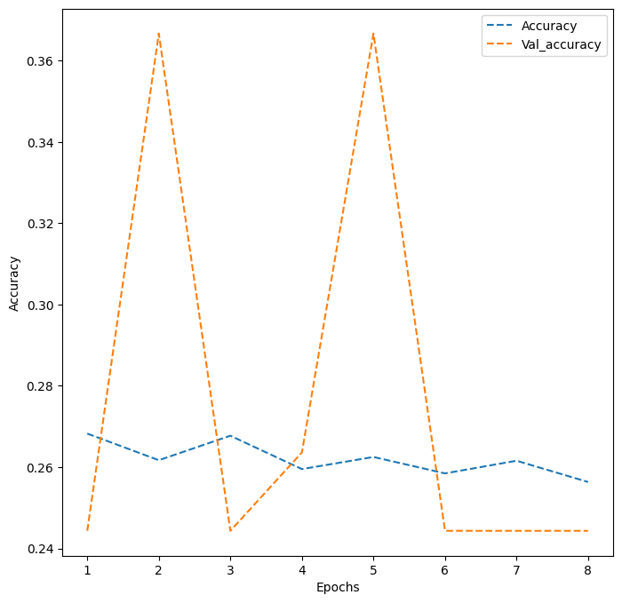

```python
# Plot training and validation accuracies
res_hist = history_res.history
list_epochs = [i for i in range(1, 9)]

plt.figure(figsize=(8, 8))

plt.plot(list_epochs, res_hist['accuracy'], ls='--', label='Accuracy')
plt.plot(list_epochs, res_hist['val_accuracy'], ls='--', label='Val_accuracy')

plt.xlabel('Epochs')
plt.ylabel('Accuracy')

plt.legend()
plt.show()
```

**Note: You can even go back and build your own architecture on top of the ResNet Transfer layer and see if you can improve the performance.**

## **EfficientNet Model**

```python
# Clear backend
backend.clear_session()

# Fixing the seed after clearing backend
random.seed(42)
np.random.seed(42)
tf.random.set_seed(42)
```

### **Model Building**

- Import EfficientNet upto the layer of your choice and add Fully Connected layers on top of it.

```python
EfficientNet = ap.EfficientNetV2B2(include_top=False, weights="imagenet", input_shape= (48, 48, 3))

EfficientNet.summary()
```

```
Downloading data from https://storage.googleapis.com/tensorflow/keras-applications/efficientnet_v2/efficientnetv2-b2_notop.h5
Model: "efficientnetv2-b2"
__________________________________________________________________________________________________
 Layer (type)                Output Shape                 Param #   Connected to
==================================================================================================
 input_1 (InputLayer)        [(None, 48, 48, 3)]          0         []

 rescaling (Rescaling)       (None, 48, 48, 3)            0         ['input_1[0][0]']

 normalization (Normalizati  (None, 48, 48, 3)            0         ['rescaling[0][0]']
 on)

 stem_conv (Conv2D)          (None, 24, 24, 32)           864       ['normalization[0][0]']

 stem_bn (BatchNormalizatio  (None, 24, 24, 32)           128       ['stem_conv[0][0]']
 n)

 stem_activation (Activatio  (None, 24, 24, 32)           0         ['stem_bn[0][0]']
 n)

 block1a_project_conv (Conv  (None, 24, 24, 16)           4608      ['stem_activation[0][0]']
 2D)

 block1a_project_bn (BatchN  (None, 24, 24, 16)           64        ['block1a_project_conv[0][0]']
 ormalization)

 block1a_project_activation  (None, 24, 24, 16)           0         ['block1a_project_bn[0][0]']
  (Activation)

 block1b_project_conv (Conv  (None, 24, 24, 16)           2304      ['block1a_project_activation[0
 2D)                                                                ][0]']

 block1b_project_bn (BatchN  (None, 24, 24, 16)           64        ['block1b_project_conv[0][0]']
 ormalization)

 block1b_project_activation  (None, 24, 24, 16)           0         ['block1b_project_bn[0][0]']
  (Activation)

 block1b_drop (Dropout)      (None, 24, 24, 16)           0         ['block1b_project_activation[0
                                                                    ][0]']
```

[output cut: 938 more lines]

```
                                                                     'block6i_add[0][0]']

 top_conv (Conv2D)           (None, 2, 2, 1408)           292864    ['block6j_add[0][0]']

 top_bn (BatchNormalization  (None, 2, 2, 1408)           5632      ['top_conv[0][0]']
 )

 top_activation (Activation  (None, 2, 2, 1408)           0         ['top_bn[0][0]']
 )

==================================================================================================
Total params: 8769374 (33.45 MB)
Trainable params: 8687086 (33.14 MB)
Non-trainable params: 82288 (321.44 KB)
__________________________________________________________________________________________________
```

```python
transfer_layer_EfficientNet = EfficientNet.get_layer('block6e_expand_activation')
EfficientNet.trainable = False

# Add your Flatten layer.
x = Flatten()(transfer_layer_EfficientNet.output)

# Add your Dense layers and/or BatchNormalization and Dropout layers
x = Dense(256, activation='relu')(x)
x = BatchNormalization()(x)
x = Dropout(0.2)(x)

x = Dense(128, activation='relu')(x)
x = BatchNormalization()(x)
x = Dropout(0.2)(x)

# Add your final Dense layer with 4 neurons and softmax activation function.
pred = Dense(4, activation='softmax')(x)

Efficientnetmodel = Model(EfficientNet.input, pred)
```

### **Compiling and Training the Model**

```python
checkpoint = ModelCheckpoint("./efficientmodel.h5", monitor = 'val_accuracy', verbose = 1, save_best_only = True, mode = 'max')

callbacks_list = [early_stopping, checkpoint, reduce_learningrate]
```

```python
# Compile the model
Efficientnetmodel.compile(optimizer=Adam(learning_rate=0.001),
                 loss='categorical_crossentropy',
                 metrics=['accuracy'])

Efficientnetmodel.summary()
```

```
Model: "model"
__________________________________________________________________________________________________
 Layer (type)                Output Shape                 Param #   Connected to
==================================================================================================
 input_1 (InputLayer)        [(None, 48, 48, 3)]          0         []

 rescaling (Rescaling)       (None, 48, 48, 3)            0         ['input_1[0][0]']

 normalization (Normalizati  (None, 48, 48, 3)            0         ['rescaling[0][0]']
 on)

 stem_conv (Conv2D)          (None, 24, 24, 32)           864       ['normalization[0][0]']

 stem_bn (BatchNormalizatio  (None, 24, 24, 32)           128       ['stem_conv[0][0]']
 n)

 stem_activation (Activatio  (None, 24, 24, 32)           0         ['stem_bn[0][0]']
 n)

 block1a_project_conv (Conv  (None, 24, 24, 16)           4608      ['stem_activation[0][0]']
 2D)

 block1a_project_bn (BatchN  (None, 24, 24, 16)           64        ['block1a_project_conv[0][0]']
 ormalization)

 block1a_project_activation  (None, 24, 24, 16)           0         ['block1a_project_bn[0][0]']
  (Activation)

 block1b_project_conv (Conv  (None, 24, 24, 16)           2304      ['block1a_project_activation[0
 2D)                                                                ][0]']

 block1b_project_bn (BatchN  (None, 24, 24, 16)           64        ['block1b_project_conv[0][0]']
 ormalization)

 block1b_project_activation  (None, 24, 24, 16)           0         ['block1b_project_bn[0][0]']
  (Activation)

 block1b_drop (Dropout)      (None, 24, 24, 16)           0         ['block1b_project_activation[0
                                                                    ][0]']

```

[output cut: 706 more lines]

```
 dense_1 (Dense)             (None, 128)                  32896     ['dropout[0][0]']

 batch_normalization_1 (Bat  (None, 128)                  512       ['dense_1[0][0]']
 chNormalization)

 dropout_1 (Dropout)         (None, 128)                  0         ['batch_normalization_1[0][0]'
                                                                    ]

 dense_2 (Dense)             (None, 4)                    516       ['dropout_1[0][0]']

==================================================================================================
Total params: 6014762 (22.94 MB)
Trainable params: 1312388 (5.01 MB)
Non-trainable params: 4702374 (17.94 MB)
__________________________________________________________________________________________________
```

```python
history_eff = Efficientnetmodel.fit(train_set,
                              epochs=20,
                              batch_size=batch_size,
                              validation_data=validation_set,
                              callbacks=callbacks_list)
```

```
Epoch 1: val_accuracy improved from -inf to 0.36669, saving model to ./efficientmodel.h5
```

```
Epoch 2: val_accuracy did not improve from 0.36669
Epoch 3: val_accuracy did not improve from 0.36669
Epoch 4: val_accuracy did not improve from 0.36669

Epoch 5: val_accuracy did not improve from 0.36669

Epoch 5: ReduceLROnPlateau reducing learning rate to 0.00020000000949949026.
Epoch 5: early stopping
```

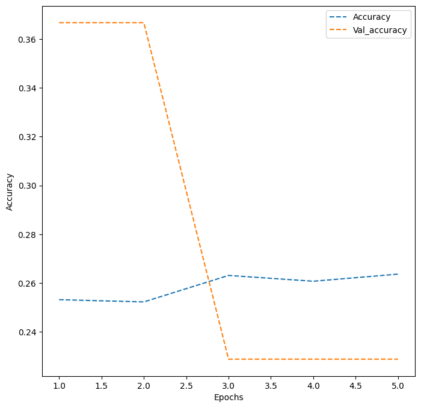

```python
# Plot training and validation accuracies
eff_hist = history_eff.history
list_epochs = [i for i in range(1, 6)]

plt.figure(figsize=(8, 8))

plt.plot(list_epochs, eff_hist['accuracy'], ls='--', label='Accuracy')
plt.plot(list_epochs, eff_hist['val_accuracy'], ls='--', label='Val_accuracy')

plt.xlabel('Epochs')
plt.ylabel('Accuracy')

plt.legend()
plt.show()
```

### **Evaluating the EfficientnetNet Model**

**Observations and Insights:** Similarly with ResNet, Effiectnet performs poorly on this dataset, most likely to do with the data not being complex enough.

**Note: You can even go back and build your own architecture on top of the VGG16 Transfer layer and see if you can improve the performance.**

**Think About It:**

- What is your overall performance of these Transfer Learning Architectures? Can we draw a comparison of these models' performances. Are we satisfied with the accuracies that we have received?
- Do you think our issue lies with 'rgb' color_mode?

**Observations:** Based on the performance from using transfer learning, VGG was the only one that showed promise, although the accuracy still wasn't satisfactory.

Now that we have tried multiple pre-trained models, let's build a complex CNN architecture and see if we can get better performance.

## **Building a Complex Neural Network Architecture**

In this section, we will build a more complex Convolutional Neural Network Model that has close to as many parameters as we had in our Transfer Learning Models. However, we will have only 1 input channel for our input images.

## **Creating our Data Loaders**

In this section, we are creating data loaders which we will use as inputs to the more Complicated Convolutional Neural Network. We will go ahead with color_mode = 'grayscale'.

```python
# Creating data generators for train, validation and test set with color_mode = 'grayscale'
datagen_train_gray = ImageDataGenerator(horizontal_flip = True,
                                    brightness_range=(0.,2.),
                                    rescale=1./255,
                                    shear_range=0.3)

train_set_gray = datagen_train_gray.flow_from_directory('Facial_emotion_images/train',
                                              target_size = (image_size, image_size),
                                              color_mode = 'grayscale',
                                              batch_size = batch_size,
                                              class_mode = 'categorical',
                                              shuffle = True)

datagen_validation_gray = ImageDataGenerator(horizontal_flip = True,
                                    brightness_range=(0.,2.),
                                    rescale=1./255,
                                    shear_range=0.3)

validation_set_gray = datagen_validation_gray.flow_from_directory('Facial_emotion_images/validation',
                                              target_size = (image_size, image_size),
                                              color_mode = 'grayscale',
                                              batch_size = batch_size,
                                              class_mode = 'categorical',
                                              shuffle = True)

datagen_test_gray = ImageDataGenerator(horizontal_flip = True,
                                    brightness_range=(0.,2.),
                                    rescale=1./255,
                                    shear_range=0.3)

test_set_gray = datagen_test_gray.flow_from_directory('Facial_emotion_images/test',
                                              target_size = (image_size, image_size),
                                              color_mode = 'grayscale',
                                              batch_size = batch_size,
                                              class_mode = 'categorical',
                                              shuffle = True)
```

```
Found 15109 images belonging to 4 classes.
Found 4977 images belonging to 4 classes.
Found 128 images belonging to 4 classes.
```

### **Model Building**

- Try building a layer with 5 Convolutional Blocks and see if performance increases.

```python
# Clear backend
backend.clear_session()

# Fixing the seed after clearing backend
random.seed(42)
np.random.seed(42)
tf.random.set_seed(42)
```

```python
# Set up input_shape with 1 channel for grayscale
input_shape=(image_size, image_size, 1)
num_classes=4

checkpoint = ModelCheckpoint("./model4.h5", monitor='val_accuracy', verbose=1, save_best_only=True, mode='max')

early_stopping = EarlyStopping(monitor = 'val_loss',
                          min_delta = 0,
                          patience = 3,
                          verbose = 1,
                          restore_best_weights = True
                          )

reduce_learningrate = ReduceLROnPlateau(monitor = 'val_loss',
                              factor = 0.2,
                              patience = 3,
                              verbose = 1,
                              min_delta = 0.0001)

callbacks_list = [early_stopping, checkpoint, reduce_learningrate]

# Define the model
def cnn_model_3(input_shape=input_shape, num_classes=num_classes):
    # Initialize the model
    model = Sequential()

    # First Conv block
    model.add(Conv2D(128, (2, 2), padding='same', activation='relu', input_shape=input_shape))
    model.add(MaxPooling2D(pool_size=(2, 2)))
    model.add(Dropout(0.2))

    # Second Convolutional Block
    model.add(Conv2D(128, (2, 2), padding='same', activation='relu'))
    model.add(MaxPooling2D(pool_size=(2, 2)))
    model.add(Dropout(0.2))

    # Third Convolutional Block
    model.add(Conv2D(256, (2, 2), padding='same', activation='relu'))
    model.add(MaxPooling2D(pool_size=(2, 2)))
    model.add(Dropout(0.2))

    # Fourth Convolutional Block
    model.add(Conv2D(512, (2, 2), padding='same', activation='relu'))
    model.add(Dropout(0.2))

    # Fifth Convolutional Block
    model.add(Conv2D(512, (2, 2), padding='same', activation='relu'))
    model.add(Dropout(0.2))

    # Flatten layer
    model.add(Flatten())

    # Dense layers
    model.add(Dense(256, activation='relu'))
    model.add(Dropout(0.2))
    model.add(Dense(512, activation='relu'))
    model.add(Dense(4, activation='softmax'))

    model.compile(optimizer=Adam(learning_rate=0.001),
                  loss='categorical_crossentropy',
                  metrics=['accuracy'])

    return model
```

### **Compiling and Training the Model**

```python
model4 = cnn_model_3()

model4.summary()
```

```
Model: "sequential"
_________________________________________________________________
 Layer (type)                Output Shape              Param #
=================================================================
 conv2d (Conv2D)             (None, 48, 48, 128)       640

 max_pooling2d (MaxPooling2  (None, 24, 24, 128)       0
 D)

 dropout (Dropout)           (None, 24, 24, 128)       0

 conv2d_1 (Conv2D)           (None, 24, 24, 128)       65664

 max_pooling2d_1 (MaxPoolin  (None, 12, 12, 128)       0
 g2D)

 dropout_1 (Dropout)         (None, 12, 12, 128)       0

 conv2d_2 (Conv2D)           (None, 12, 12, 256)       131328

 max_pooling2d_2 (MaxPoolin  (None, 6, 6, 256)         0
 g2D)

 dropout_2 (Dropout)         (None, 6, 6, 256)         0

 conv2d_3 (Conv2D)           (None, 6, 6, 512)         524800

 dropout_3 (Dropout)         (None, 6, 6, 512)         0

 conv2d_4 (Conv2D)           (None, 6, 6, 512)         1049088

 dropout_4 (Dropout)         (None, 6, 6, 512)         0

 flatten (Flatten)           (None, 18432)             0

 dense (Dense)               (None, 256)               4718848

 dropout_5 (Dropout)         (None, 256)               0

 dense_1 (Dense)             (None, 512)               131584

 dense_2 (Dense)             (None, 4)                 2052

=================================================================
Total params: 6624004 (25.27 MB)
Trainable params: 6624004 (25.27 MB)
Non-trainable params: 0 (0.00 Byte)
_________________________________________________________________
```

```python
history3 = model4.fit(train_set_gray,
                     epochs=20,
                     validation_data=validation_set_gray,
                     callbacks=callbacks_list)
```

```
Epoch 1: val_accuracy improved from -inf to 0.35624, saving model to ./model4.h5
```

```
Epoch 2: val_accuracy improved from 0.35624 to 0.44002, saving model to ./model4.h5
Epoch 3: val_accuracy improved from 0.44002 to 0.50894, saving model to ./model4.h5
Epoch 4: val_accuracy improved from 0.50894 to 0.53586, saving model to ./model4.h5
Epoch 5: val_accuracy improved from 0.53586 to 0.55033, saving model to ./model4.h5
Epoch 6: val_accuracy improved from 0.55033 to 0.56922, saving model to ./model4.h5
Epoch 7: val_accuracy improved from 0.56922 to 0.60378, saving model to ./model4.h5
Epoch 8: val_accuracy did not improve from 0.60378
Epoch 9: val_accuracy improved from 0.60378 to 0.62568, saving model to ./model4.h5
Epoch 10: val_accuracy did not improve from 0.62568
Epoch 11: val_accuracy improved from 0.62568 to 0.63613, saving model to ./model4.h5
Epoch 12: val_accuracy improved from 0.63613 to 0.64456, saving model to ./model4.h5
Epoch 13: val_accuracy did not improve from 0.64456
Epoch 14: val_accuracy did not improve from 0.64456

Epoch 15: val_accuracy did not improve from 0.64456

Epoch 15: ReduceLROnPlateau reducing learning rate to 0.00020000000949949026.
Epoch 15: early stopping
```

### **Evaluating the Model on Test Set**

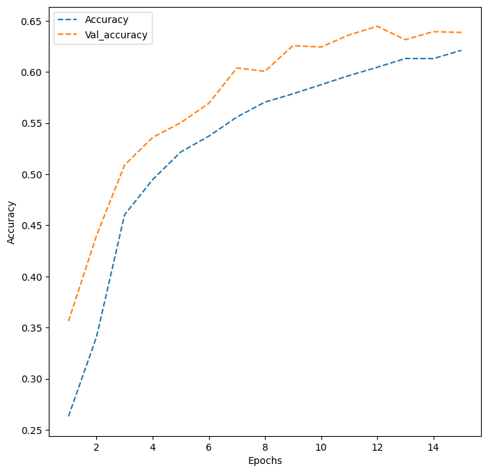

```python
# Plot training and validation accuracies
dict_hist3 = history3.history
list_epochs = [i for i in range(1, 16)]

plt.figure(figsize=(8, 8))

plt.plot(list_epochs, dict_hist3['accuracy'], ls='--', label='Accuracy')
plt.plot(list_epochs, dict_hist3['val_accuracy'], ls='--', label='Val_accuracy')

plt.xlabel('Epochs')
plt.ylabel('Accuracy')

plt.legend()
plt.show()
```

**Observations and Insights:** This model didn't perform better than the earlier models. This code be either because the model was too complex, so reducing the amount of nodes in each layer could increase performance, or we may require more data to be able to train a model from scratch with a satisfactory performance.

### **Plotting the Confusion Matrix for the chosen final model**

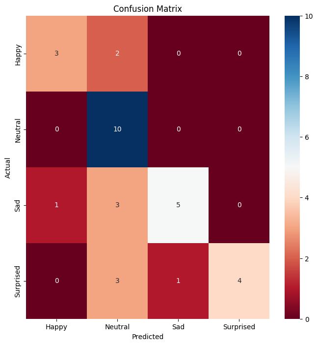

```python
pred = vggmodel.predict(test_images)

# Turn predicted values into single values
pred = np.argmax(pred, axis=1)
y_true = np.argmax(test_labels, axis=1)

cm = confusion_matrix(y_true, pred)

# Get class labels
classes = ['Happy', 'Neutral', 'Sad', 'Surprised']

# Plot the heatmap
plt.figure(figsize=(8, 8))
sns.heatmap(cm, annot=True, fmt='.0f', xticklabels=classes, yticklabels=classes, cmap='RdBu')

# Set labels and title
plt.xlabel('Predicted')
plt.ylabel('Actual')
plt.title('Confusion Matrix')

# Show the plot
plt.show()
```

**Observations and Insights:** While VGG appeared to have performed slightly worse on the test data, it is most likely that on a much larger set of test data it will generalize better than the other models.

## **Conclusion:**

In conclusion, VGG would be my choice of network to proceed with. The fact that the majority of incorrect guesses were neutral, looking through the pictures that were incorrectly labelled as neutral would be a good next step to see what the actual reason for this was.

After this we can test if increasing the threshold for selecting neutral classes could increase the performance. If all of the correct choices for neutral were above, say, 70%, but when they were incorrectly labelled the model predicted 60% neutral, 30% the correct class and 10% the other 2, this could result in a good model.

If this doesn't prove to be helpful, my next step would be to try and increase the complexity slowly to try and be able to capture the underlying patterns better, along with tuning other hyperparameters such as batch_size, dropout amount and number of nodes in each layer.

### **Refined insights**:

- What are the most meaningful insights from the data relevant to the problem?

### **Comparison of various techniques and their relative performance**:

- How do different techniques perform? Which one is performing relatively better? Is there scope to improve the performance further?

### **Proposal for the final solution design**:

- What model do you propose to be adopted? Why is this the best solution to adopt?

# **Improvements**

As VGG showed the most promise, I will focus on tuning the model to achieve the best accuracy I can. I will start by building a model and training it for a baseline, and then tune the hyperparameters to find the best combination.

```python
# Input shape with of image_size x image_size, and 3 channels for rgb
input_shape=(image_size, image_size, 3)
num_classes=4

# Save the best model in model1.h5
checkpoint = ModelCheckpoint("./final_model.h5", monitor='val_accuracy', verbose=1, save_best_only=True, mode='max')

# Stop early if loss function doesn't improve
early_stopping = EarlyStopping(monitor = 'val_loss',
                          min_delta = 0,
                          patience = 3,
                          verbose = 1,
                          restore_best_weights = True
                          )

# Reduce learning rate if loss starts to plateau
reduce_learningrate = ReduceLROnPlateau(monitor = 'val_loss',
                              factor = 0.2,
                              patience = 3,
                              verbose = 1,
                              min_delta = 0.0001)

callbacks_list = [early_stopping, checkpoint, reduce_learningrate]
```

```python
def final_model(input_shape=input_shape, num_classes=4, learning_rate=0.001, neurons=256, dropout=0.1):
    vgg = VGG16(include_top=False, weights='imagenet', input_shape=(input_shape))

    # Copy up to specified layer
    transfer_layer = vgg.get_layer('block5_conv1')

    # Set the weights to not be trained
    vgg.trainable = False

    # Flatten the output from the specified block of the VGG16 model
    x = Flatten()(transfer_layer.output, training=False)

    # Add a Dense layer with 256 neurons
    x = Dense(neurons, activation='relu')(x)
    x = Dropout(dropout)(x)

    # Add an output layer with 4 nearons
    pred = Dense(num_classes, activation='softmax')(x)

    model = Model(vgg.input, pred)

    # Compile the model
    model.compile(optimizer=Adam(
        learning_rate=learning_rate),
        loss='categorical_crossentropy',
        metrics=['accuracy']
    )

    return model
```

```python
base_model = final_model()
```

```python
history = base_model.fit(
    train_set,
    epochs=10,
    batch_size=batch_size,
    validation_data=validation_set,
    callbacks=callbacks_list
)
```

```
WARNING:tensorflow:From C:\Users\david.bunyan\AppData\Local\Packages\PythonSoftwareFoundation.Python.3.11_qbz5n2kfra8p0\LocalCache\local-packages\Python311\site-packages\keras\src\utils\tf_utils.py:492: The name tf.ragged.RaggedTensorValue is deprecated. Please use tf.compat.v1.ragged.RaggedTensorVa…

WARNING:tensorflow:From C:\Users\david.bunyan\AppData\Local\Packages\PythonSoftwareFoundation.Python.3.11_qbz5n2kfra8p0\LocalCache\local-packages\Python311\site-packages\keras\src\engine\base_layer_utils.py:384: The name tf.executing_eagerly_outside_functions is deprecated. Please use tf.compat.v1.e…

Epoch 1: val_accuracy improved from -inf to 0.56420, saving model to .\final_model.h5
```

```
Epoch 2: val_accuracy improved from 0.56420 to 0.58489, saving model to .\final_model.h5
Epoch 3: val_accuracy did not improve from 0.58489
Epoch 4: val_accuracy improved from 0.58489 to 0.60016, saving model to .\final_model.h5
Epoch 5: val_accuracy improved from 0.60016 to 0.60297, saving model to .\final_model.h5
Epoch 6: val_accuracy did not improve from 0.60297
Epoch 7: val_accuracy did not improve from 0.60297

Epoch 8: val_accuracy improved from 0.60297 to 0.60920, saving model to .\final_model.h5

Epoch 8: ReduceLROnPlateau reducing learning rate to 0.00020000000949949026.
Epoch 8: early stopping
```

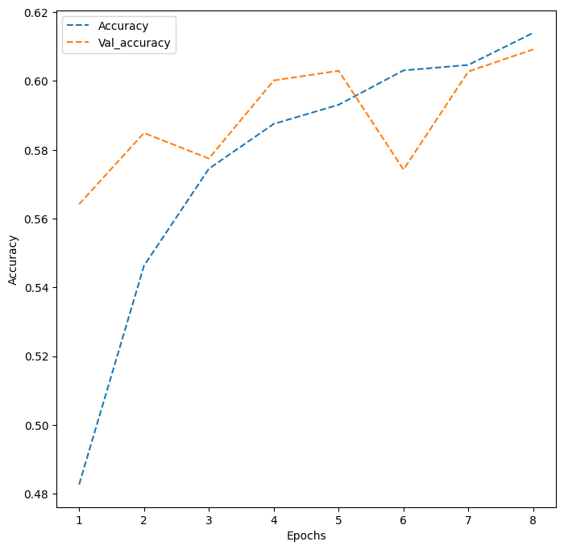

```python
# Plot training and validation accuracies
dict_hist = history.history
list_epochs = [i for i in range(1, 9)]

plt.figure(figsize=(8, 8))

plt.plot(list_epochs, dict_hist['accuracy'], ls='--', label='Accuracy')
plt.plot(list_epochs, dict_hist['val_accuracy'], ls='--', label='Val_accuracy')

plt.xlabel('Epochs')
plt.ylabel('Accuracy')

plt.legend()
plt.show()
```

After 8 epochs, the accuracy and val_accuracy were close, both around 61. I will now use optuna to tune the following hyperparameters:  
- learning rate  
- dropout rate  
- number of fully connected layers  
- number of neurons per layer  
- batch size

```python
import optuna

# Copy up to the specified pooling layer
transfer_layer = vgg.get_layer('block5_conv1')

# Set the weights to not be trained
vgg.trainable = False



def objective(trial):
    # Define the hyperparameters to be tuned
    learning_rate = trial.suggest_float('learning_rate', 1e-5, 1e-2, log=True)
    dropout_rate = trial.suggest_float('dropout_rate', 0.0, 0.5)
    num_fc_layers = trial.suggest_int('num_fc_layers', 1, 3)
    neurons_per_layer = [trial.suggest_int(f'neurons_layer_{i}', 32, 256) for i in range(num_fc_layers)]
    batch_size = trial.suggest_int('batch_size', 32, 128)

    # Flatten the output from the specified block of the VGG16 model
    x = Flatten()(transfer_layer.output, training=False)

    # Add fully connected layers with the specified number of neurons
    for neurons in neurons_per_layer:
        x = Dense(neurons, activation='relu')(x)
        x = Dropout(dropout_rate)(x)

    # Adding the final dense layer with 4 neurons and using 'softmax' activation
    pred = Dense(4, activation='softmax')(x)

    # Initializing the model
    model = Model(vgg.input, pred)

    # Compile the model
    model.compile(optimizer=Adam(learning_rate=learning_rate), loss='categorical_crossentropy', metrics=['accuracy'])

    # Train the model
    history = model.fit(train_set, epochs=10, batch_size=batch_size, validation_data=validation_set, verbose=0)

    # Evaluate the model
    val_acc = history.history['val_accuracy'][-1]

    return val_acc
```

```python
# Create a study object and optimize
study = optuna.create_study(direction='maximize')
study.optimize(objective, n_trials=50)

# Print the best parameters
print('Number of finished trials: ', len(study.trials))
print('Best trial:')
trial = study.best_trial

print('Value: ', trial.value)
print('Params: ')
for key, value in trial.params.items():
    print(f'    {key}: {value}')
```

```
[I 2023-12-13 20:18:22,719] A new study created in memory with name: no-name-3e37356a-b48d-42dc-a6ff-993f82bfa118
[I 2023-12-13 20:24:32,259] Trial 0 finished with value: 0.5547518730163574 and parameters: {'learning_rate': 0.0012396477092215434, 'dropout_rate': 0.4020818378304192, 'num_fc_layers': 1, 'neurons_layer_0': 136, 'batch_size': 113}. Best is trial 0 with value: 0.5547518730163574.
[I 2023-12-13 20:30:53,319] Trial 1 finished with value: 0.24432389438152313 and parameters: {'learning_rate': 0.00763634607598533, 'dropout_rate': 0.41403562639912267, 'num_fc_layers': 2, 'neurons_layer_0': 219, 'neurons_layer_1': 87, 'batch_size': 88}. Best is trial 0 with value: 0.554751873016357…
[I 2023-12-13 20:37:13,861] Trial 2 finished with value: 0.6057866215705872 and parameters: {'learning_rate': 0.0015424028689274133, 'dropout_rate': 0.0023090639187137163, 'num_fc_layers': 1, 'neurons_layer_0': 122, 'batch_size': 105}. Best is trial 2 with value: 0.6057866215705872.
[I 2023-12-13 20:43:38,237] Trial 3 finished with value: 0.581474781036377 and parameters: {'learning_rate': 0.00011280264915171732, 'dropout_rate': 0.21865600383788436, 'num_fc_layers': 3, 'neurons_layer_0': 120, 'neurons_layer_1': 42, 'neurons_layer_2': 176, 'batch_size': 101}. Best is trial 2 wit…
[I 2023-12-13 20:50:36,014] Trial 4 finished with value: 0.5085392594337463 and parameters: {'learning_rate': 0.0012592153237387152, 'dropout_rate': 0.3473420328777158, 'num_fc_layers': 2, 'neurons_layer_0': 132, 'neurons_layer_1': 191, 'batch_size': 80}. Best is trial 2 with value: 0.60578662157058…
[I 2023-12-13 21:00:31,827] Trial 5 finished with value: 0.5830821990966797 and parameters: {'learning_rate': 0.0003863324424014293, 'dropout_rate': 0.39601865374828227, 'num_fc_layers': 1, 'neurons_layer_0': 41, 'batch_size': 70}. Best is trial 2 with value: 0.6057866215705872.
[I 2023-12-13 21:07:36,037] Trial 6 finished with value: 0.5897126793861389 and parameters: {'learning_rate': 0.0001066876398278956, 'dropout_rate': 0.2740877806849563, 'num_fc_layers': 3, 'neurons_layer_0': 193, 'neurons_layer_1': 37, 'neurons_layer_2': 145, 'batch_size': 127}. Best is trial 2 with…
[I 2023-12-13 21:14:43,242] Trial 7 finished with value: 0.5997588634490967 and parameters: {'learning_rate': 0.00021517380243839276, 'dropout_rate': 0.12720936472599237, 'num_fc_layers': 1, 'neurons_layer_0': 165, 'batch_size': 83}. Best is trial 2 with value: 0.6057866215705872.
[I 2023-12-13 21:21:55,152] Trial 8 finished with value: 0.5571629405021667 and parameters: {'learning_rate': 0.0020287351251271797, 'dropout_rate': 0.3475254183040835, 'num_fc_layers': 2, 'neurons_layer_0': 135, 'neurons_layer_1': 41, 'batch_size': 93}. Best is trial 2 with value: 0.605786621570587…
[I 2023-12-13 21:29:04,256] Trial 9 finished with value: 0.5228049159049988 and parameters: {'learning_rate': 1.2092879468898486e-05, 'dropout_rate': 0.3150323995179026, 'num_fc_layers': 2, 'neurons_layer_0': 247, 'neurons_layer_1': 132, 'batch_size': 73}. Best is trial 2 with value: 0.6057866215705…
[I 2023-12-13 21:36:07,487] Trial 10 finished with value: 0.4864376187324524 and parameters: {'learning_rate': 0.009808151732210398, 'dropout_rate': 0.0023526172939174503, 'num_fc_layers': 1, 'neurons_layer_0': 69, 'batch_size': 41}. Best is trial 2 with value: 0.6057866215705872.
[I 2023-12-13 21:43:17,810] Trial 11 finished with value: 0.5997588634490967 and parameters: {'learning_rate': 0.0002191393858275668, 'dropout_rate': 0.02314556788091557, 'num_fc_layers': 1, 'neurons_layer_0': 186, 'batch_size': 55}. Best is trial 2 with value: 0.6057866215705872.
[I 2023-12-13 21:50:27,767] Trial 12 finished with value: 0.5838858485221863 and parameters: {'learning_rate': 3.008012312292099e-05, 'dropout_rate': 0.11270899726613981, 'num_fc_layers': 1, 'neurons_layer_0': 92, 'batch_size': 108}. Best is trial 2 with value: 0.6057866215705872.
```

[output cut: 37 more lines]

```
Number of finished trials:  50
Best trial:
Value:  0.6196503639221191
Params:
    learning_rate: 0.00011414102410710657
    dropout_rate: 0.05437381104515301
    num_fc_layers: 1
    neurons_layer_0: 211
    batch_size: 105
```

```python
# Clear the backend
backend.clear_session()

# Reset the seeds
random.seed(42)
np.random.seed(42)
tf.random.set_seed(42)
```

```python
learning_rate = trial.params['learning_rate']
dropout = trial.params['dropout_rate']
neurons = trial.params['neurons_layer_0']
batch_size = trial.params['batch_size']

# Create model with hyperparameters learned from tuning
model = final_model(learning_rate=learning_rate, dropout=dropout, neurons=neurons)
```

```python
# Save the best model in model1.h5
checkpoint = ModelCheckpoint("./final_model.h5", monitor='val_accuracy', verbose=1, save_best_only=True, mode='max')

# Stop early if loss function doesn't improve
early_stopping = EarlyStopping(monitor = 'val_loss',
                          min_delta = 0,
                          patience = 5,
                          verbose = 1,
                          restore_best_weights = True
                          )

# Reduce learning rate if loss starts to plateau
reduce_learningrate = ReduceLROnPlateau(monitor = 'val_loss',
                              factor = 0.2,
                              patience = 3,
                              verbose = 1,
                              min_delta = 0.00001)

callbacks_list = [early_stopping, checkpoint, reduce_learningrate]
```

```python
history = model.fit(
    train_set,
    epochs=50,
    batch_size=batch_size,
    validation_data=validation_set,
    callbacks=callbacks_list
)
```

```
Epoch 1: val_accuracy improved from -inf to 0.51979, saving model to .\final_model.h5
```

```
Epoch 2: val_accuracy improved from 0.51979 to 0.55857, saving model to .\final_model.h5
Epoch 3: val_accuracy did not improve from 0.55857
Epoch 4: val_accuracy improved from 0.55857 to 0.57484, saving model to .\final_model.h5
Epoch 5: val_accuracy improved from 0.57484 to 0.58750, saving model to .\final_model.h5
Epoch 6: val_accuracy did not improve from 0.58750
Epoch 7: val_accuracy improved from 0.58750 to 0.61242, saving model to .\final_model.h5
Epoch 8: val_accuracy did not improve from 0.61242
Epoch 9: val_accuracy did not improve from 0.61242
Epoch 10: val_accuracy improved from 0.61242 to 0.61503, saving model to .\final_model.h5
Epoch 11: val_accuracy did not improve from 0.61503
Epoch 12: val_accuracy improved from 0.61503 to 0.61945, saving model to .\final_model.h5
Epoch 13: val_accuracy did not improve from 0.61945
Epoch 14: val_accuracy improved from 0.61945 to 0.62287, saving model to .\final_model.h5
Epoch 15: val_accuracy did not improve from 0.62287
Epoch 16: val_accuracy did not improve from 0.62287
Epoch 17: val_accuracy did not improve from 0.62287

Epoch 17: ReduceLROnPlateau reducing learning rate to 2.282820496475324e-05.
Epoch 18: val_accuracy did not improve from 0.62287
Epoch 19: val_accuracy improved from 0.62287 to 0.62628, saving model to .\final_model.h5
Epoch 20: val_accuracy improved from 0.62628 to 0.63090, saving model to .\final_model.h5
Epoch 21: val_accuracy did not improve from 0.63090
Epoch 22: val_accuracy did not improve from 0.63090
Epoch 23: val_accuracy did not improve from 0.63090

Epoch 23: ReduceLROnPlateau reducing learning rate to 4.565640847431496e-06.
Epoch 24: val_accuracy improved from 0.63090 to 0.63271, saving model to .\final_model.h5

Epoch 25: val_accuracy improved from 0.63271 to 0.63914, saving model to .\final_model.h5
Epoch 25: early stopping
```

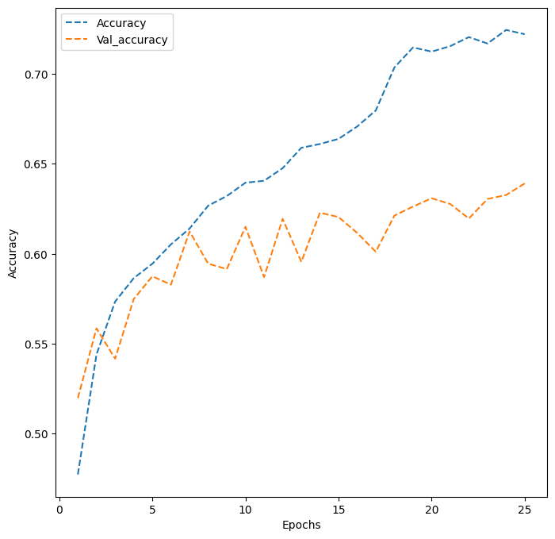

```python
# Plot training and validation accuracies
dict_hist = history.history
list_epochs = [i for i in range(1, 26)]

plt.figure(figsize=(8, 8))

plt.plot(list_epochs, dict_hist['accuracy'], ls='--', label='Accuracy')
plt.plot(list_epochs, dict_hist['val_accuracy'], ls='--', label='Val_accuracy')

plt.xlabel('Epochs')
plt.ylabel('Accuracy')

plt.legend()
plt.show()
```

Now that I have trained a model, I am going set set the previous layers to trainable and train it with a small learning rate to fine tune it

```python
vgg.trainable = True

model.compile(
    optimizer=Adam(1e-6),
    loss='categorical_crossentropy',
    metrics=['accuracy']
)

# Save the best model in model1.h5
checkpoint = ModelCheckpoint("./final_model.h5", monitor='val_accuracy', verbose=1, save_best_only=True, mode='max')

# Stop early if loss function doesn't improve
early_stopping = EarlyStopping(monitor = 'val_loss',
                          min_delta = 0,
                          patience = 5,
                          verbose = 1,
                          restore_best_weights = True
                          )

# Reduce learning rate if loss starts to plateau
reduce_learningrate = ReduceLROnPlateau(monitor = 'val_loss',
                              factor = 0.2,
                              patience = 3,
                              verbose = 1,
                              min_delta = 0.00000001)

callbacks_list = [early_stopping, checkpoint, reduce_learningrate]

history_ft = model.fit(
    train_set,
    epochs=50,
    batch_size=batch_size,
    validation_data=validation_set,
    callbacks=callbacks_list
)
```

```
Epoch 1: val_accuracy improved from -inf to 0.63633, saving model to .\final_model.h5
```

```
Epoch 2: val_accuracy did not improve from 0.63633
Epoch 3: val_accuracy did not improve from 0.63633
Epoch 4: val_accuracy improved from 0.63633 to 0.64416, saving model to .\final_model.h5
Epoch 5: val_accuracy did not improve from 0.64416
Epoch 6: val_accuracy did not improve from 0.64416
Epoch 7: val_accuracy did not improve from 0.64416

Epoch 7: ReduceLROnPlateau reducing learning rate to 1.9999999949504855e-07.
Epoch 8: val_accuracy did not improve from 0.64416

Epoch 9: val_accuracy did not improve from 0.64416
Epoch 9: early stopping
```

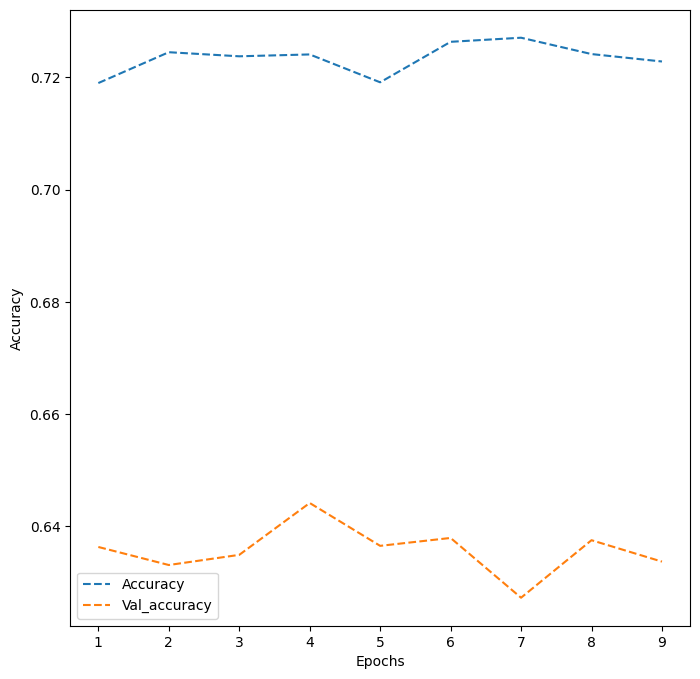

```python
# Plot training and validation accuracies
dict_hist = history_ft.history
list_epochs = [i for i in range(1, 10)]

plt.figure(figsize=(8, 8))

plt.plot(list_epochs, dict_hist['accuracy'], ls='--', label='Accuracy')
plt.plot(list_epochs, dict_hist['val_accuracy'], ls='--', label='Val_accuracy')

plt.xlabel('Epochs')
plt.ylabel('Accuracy')

plt.legend()
plt.show()
```

While a slight improvement in validation accuracy was achieved, there is still a large gap between accuracy and validation accuracy. This suggests the model is overfitting, and perhaps adding some batch normalization or increasing the dropout could see some good results

```python
from tensorflow.keras.optimizers import SGD

vgg.trainable = False

model.compile(
    optimizer=SGD(learning_rate=1e-6),
    loss='categorical_crossentropy',
    metrics=['accuracy']
)
# Save the best model in model1.h5
checkpoint = ModelCheckpoint("./final_model_sgd.h5", monitor='val_accuracy', verbose=1, save_best_only=True, mode='max')

# Stop early if loss function doesn't improve
early_stopping = EarlyStopping(monitor = 'val_loss',
                          min_delta = 0,
                          patience = 3,
                          verbose = 1,
                          restore_best_weights = True
                          )

# Reduce learning rate if loss starts to plateau
reduce_learningrate = ReduceLROnPlateau(monitor = 'val_loss',
                              factor = 0.2,
                              patience = 3,
                              verbose = 1,
                              min_delta = 0.00000001)

callbacks_list = [early_stopping, checkpoint, reduce_learningrate]

history_sgd = model.fit(
    train_set,
    epochs=50,
    batch_size=64,
    validation_data=validation_set,
    callbacks=callbacks_list
)
```

```
Epoch 1: val_accuracy improved from -inf to 0.63070, saving model to .\final_model_sgd.h5
Epoch 2: val_accuracy improved from 0.63070 to 0.63874, saving model to .\final_model_sgd.h5
Epoch 3: val_accuracy did not improve from 0.63874

Epoch 4: val_accuracy did not improve from 0.63874

Epoch 4: ReduceLROnPlateau reducing learning rate to 1.9999999949504855e-07.
Epoch 4: early stopping
```

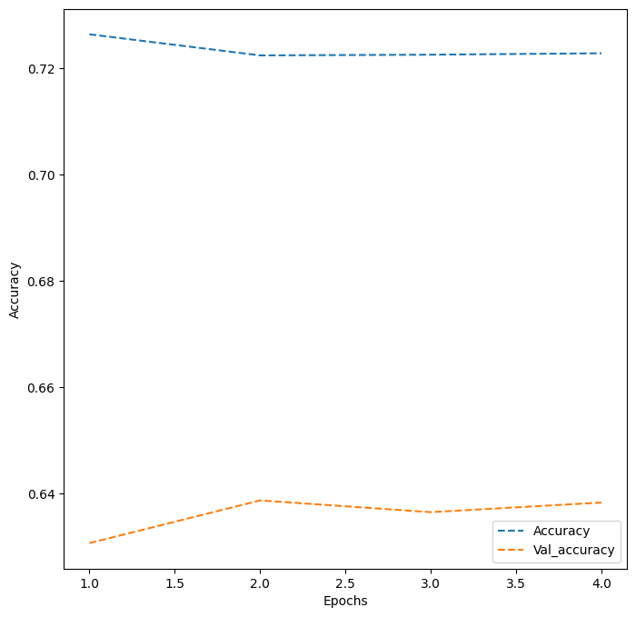

```python
# Plot training and validation accuracies
dict_hist = history_sgd.history
list_epochs = [i for i in range(1, 5)]

plt.figure(figsize=(8, 8))

plt.plot(list_epochs, dict_hist['accuracy'], ls='--', label='Accuracy')
plt.plot(list_epochs, dict_hist['val_accuracy'], ls='--', label='Val_accuracy')

plt.xlabel('Epochs')
plt.ylabel('Accuracy')

plt.legend()
plt.show()
```

```
              precision    recall  f1-score   support

           0       1.00      0.75      0.86         8
           1       0.50      1.00      0.67         5
           2       0.75      0.43      0.55         7
           3       1.00      1.00      1.00        12

    accuracy                           0.81        32
   macro avg       0.81      0.79      0.77        32
weighted avg       0.87      0.81      0.81        32
```

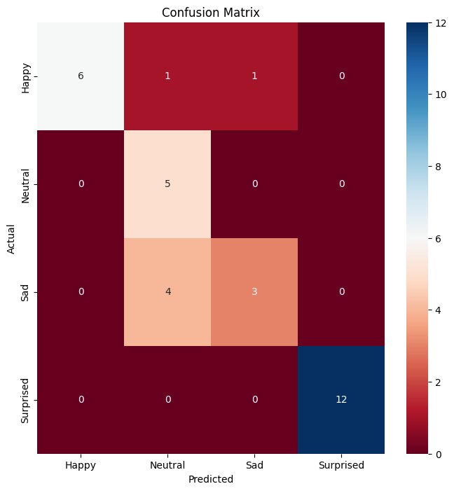

```python
test_images, test_labels = next(test_set)

pred = model.predict(test_images)

# Turn predicted values into single values
pred = np.argmax(pred, axis=1)
y_true = np.argmax(test_labels, axis=1)

cm = confusion_matrix(y_true, pred)

print(classification_report(y_true, pred))
# Get class labels
classes = ['Happy', 'Neutral', 'Sad', 'Surprised']

# Plot the heatmap
plt.figure(figsize=(8, 8))
sns.heatmap(cm, annot=True, fmt='.0f', xticklabels=classes, yticklabels=classes, cmap='RdBu')

# Set labels and title
plt.xlabel('Predicted')
plt.ylabel('Actual')
plt.title('Confusion Matrix')

# Show the plot
plt.show()
```

The model seems to perform extremely well on the surprised emotion, and very well on the happy emotion. Finding models which perform similarly on the other emotions and then using an ensemble technique could be a possible solution to increase performance